# Adverse effect of bexaroten therapy in T-lymphom

Jiri Baloun

Compiled on: **2025-11-06** Last updated **2025-11-11

# 1 Basic Description

This report investigates outcomes in patients with T-cell lymphoma treated with bexarotene and evaluates whether early-stage disease (stage_early) is associated with response and time-to-event endpoints. The overarching goal is twofold: (i) to characterise the analytic cohort and data structure, and (ii) to estimate the effect of stage_early on key clinical outcomes, both unadjusted and after sequential adjustment for clinically relevant covariates.

Objectives - Describe the cohort and data quality (sample size, distributions, missingness) and explore structure among numeric and categorical variables. - Quantify the relationship between stage_early and: (a) response_achieved (binary), (b) three survival endpoints (time_to_next_treatment, treatment_duration, response_duration), and (c) response_time_to among observations with y > 0 (continuous). - Examine robustness by adding one covariate at a time to the base models containing stage_early, and summarise stage-specific effects to aid interpretation.

Analysis plan and reporting - EDA: We use skimr to summarise variables; quantify numeric associations via Spearman’s rank correlation (Hmisc rcorr for r and p) and visualise a lower-triangle heatmap with non-significant cells masked at α = 0.05; assess associations between categorical variables and stage_early using Pearson’s chi-square (all expected counts ≥ 5) or Fisher’s exact test otherwise. - Main models: Logistic regression for response_achieved; Cox proportional hazards models for each survival endpoint; linear regression for response_time_to (y > 0). We report effect sizes (OR, HR, or mean difference) with 95% CI and exact two-sided p-values. For interpretation, stage-specific estimates (probabilities/means) are derived via emmeans, and Kaplan–Meier curves (overall and by stage) are provided with medians and 95% CI. - Sequentially adjusted models: For each covariate, we fit outcome ~ stage_early + covariate (and, where feasible, outcome ~ stage_early * covariate) to recover stage-specific effects using emmeans/emtrends for logistic and linear families, and stratified Cox (stage-specific models) for survival. Results are exported as tables and accompanied by concise narrative summaries. - Assumptions/diagnostics: Logistic models are monitored for (quasi)separation; Cox models assume proportional hazards (results interpreted cautiously given sample size); linear models assume approximate normality and homoscedasticity (restriction to y > 0 mitigates zero-inflation). Analyses use complete-case records without imputation. All p-values are unadjusted and interpreted in context.

# 2 Abbreviations

| Feature | Description | Abbreviation |
| --- | --- | --- |
| Initials | XX = surname, forename | initials |
| Center | CZ/DE | center |
| Age | at the time of initiation of Bexaroten (years) | age |
| Sex | M/F | sex |
| BMI | at the time of initiation of Bexarotene | bmi |
| PS ECOG | at the time of initiation of Bexarotene | ps_ecog |
| CTCL type | according to WHO-EORTC 2018 | ctcl_type |
| Stage | at the time of initiation of Bexarotene | stage |
| Early Stage? | 1= yes 0= no | stage_early |
| T | at the time of initiation of Bexarotene | t_stage |
| N | at the time of initiation of Bexarotene | n_stage |
| M | at the time of initiation of Bexarotene | m_stage |
| B | at the time of initiation of Bexarotene | b_stage |
| Time since Dg. | at the time of initiation of Bexarotene (months) | months_since_diagnosis |
| Time since 1. clin. manifestation | Before the initiation of Bexarotene (months) | months_since_first_symptom |
| Radiologic Examinations | Dg. Procedures, such as CT, PET, USG.. Any time during the course of disease (0=only clin. Exam.) | radiologic_exams |
| SDT before | Skin directed therapy preceding the initiation of bexarotene, incl. Radiotherapy | sdt_before |
| SysTh before | Systemic treatments preceding the initiation of bexarotene (incl. + TSEI with > 50% BSA) + TSEI >50% BSA | systh_before |
| First syst, Therapy? | 1= yes 0= no | first_syst_th |
| Initial dose | Daily Dose (mg/m²) | initial_dose_mg_m2 |
| Final dose | The highest tolerable daily dose (mg/m²) | final_dose_mg_m2 |
| Initial SysTh | Other antineoplastic Systemic therapies at the time of initiation of Bexarotene | initial_systh |
| SysTh during the Treatment | Other antineoplastic Systemic therapies during the treatment with bexarotene (duration in months) | systh_during_treatment |
| SDT during the Treatment | Skin directed Therapy during the treatment with bexarotene | sdt_during_treatment |
| Best treatment response | SD, PR, CR | response_best |
| Response? | 1=PR, CR, 0= SD,PD | response_achieved |
| MonoTh? | was the best treatment response achieved during the monotherapy (1=yes, 0=no) | monotherapy |
| Time to Response | time to achieve the best treatment response (0=only SD achieved) | response_time_to |
| Duration of response | until progression or last visit (months) | response_duration |
| Progression? | progression during the treatment (1=yes, 0=no) | progression |
| Duration of treatment | (months) | treatment_duration |
| Reason to discontinuation | 0=treatment continues | discontinuation_reason |
| Discontinued because of AE? | 1=yes, 0=no | discontinued_due_to_ae |
| TTNT | TTNT (x = TTNT not achieved ) | ttnt |
| TTNT achieved? | 1=yes, 0=no (no “next treatment” given) | ttnt_achieved |
| Comorbidities |  | comorbidities |
| Dyslipidemia before bexaroten? | 1=yes, 0=no | dyslipidemia_before |
| Thyroid disease before bexarotene? | 1=yes, 0=no | thyroid_disease_before |
| Adverse events (treatment) | (all grades) | ae_complete_all |
| AE Grade 3 / 4 (event. 5) |  | ae_complete_grade_3_4 |
| AE Grade 3/4 | 1=yes, 0=no | ae_grade_3_4 |
| AE hyperTAG any Grade? | 1=yes, 0=no | ae_hyperTAG_any |
| AE hyperTAG Grade 3/4? | 1=yes, 0=no | ae_hyperTAG_grade_3_4 |
| AE Liver Tests elevation (any grade) | 1=yes, 0=no | ae_liver |
| Haematologic AE (any grade) | 1=yes, 0=no | ae_hemato |

# 3 Methods

Design - Retrospective observational study of patients receiving bexarotene for cutaneous T-cell lymphoma. The analysis is exploratory and hypothesis-generating.

Data source and reproducibility - The analytic dataset (`d04`) is imported via the project initialisation script (`OBJ_01.R`) and, if unavailable, from a versioned snapshot (`reports/markD_03.RData`). Processing steps are scripted in R Markdown; session details (R version and packages) appear in Session info.

Participants - All cases available in `d04` are eligible. Analytic sample sizes vary by model due to listwise exclusion for missing values in variables required for a given analysis; model-wise N corresponds to the number of complete cases passed to each fit.

Data preparation - Column names are harmonised (lower snake_case) and aliases are resolved to canonical variable names per Abbreviations. Time variables are parsed with tolerant numeric conversion. Analyses use complete-case handling for variables required by a given model; no imputation is performed.

Exploratory analysis - Descriptive summaries are produced with `skimr`. Pairwise associations between numeric variables are quantified using Spearman’s rank correlation (Hmisc `rcorr` for r and p), visualised by heatmaps with non-significant cells blanked at p ≥ 0.05. Associations between categorical variables and `stage_early` are assessed via Pearson’s chi-square when all expected counts are ≥ 5; otherwise Fisher’s exact test is used.

Primary (main-effects) models - Logistic regression. `response_achieved ~ stage_early`. Effects are reported as odds ratios (OR) with 95% confidence intervals (CI) and two-sided Wald p-values. Stage-specific odds and 95% CI are derived from `emmeans` contrasts to aid interpretation. - Cox proportional hazards regression. Each survival endpoint is modelled as `Surv(time, event) ~ stage_early`. Effects are reported as hazard ratios (HR) with 95% CI and two-sided Wald p-values. Kaplan–Meier curves (overall and by stage) are generated for descriptive purposes; median survival times and 95% CI (via `survminer::surv_median`) are referenced for interpretation. - Linear regression. `response_time_to ~ stage_early` among observations with y > 0. Effects are reported as mean differences with 95% CI and two-sided p-values. Stage-specific estimates are obtained using `emmeans` contrasts.

Sequentially adjusted models - For each prespecified covariate, we fit outcome `~ stage_early + covariate` and, where feasible, outcome `~ stage_early * covariate` to recover stage-specific effects using `emmeans`/`emtrends`. Modelling families match the outcome type (binomial for binary, Cox PH for survival, Gaussian for continuous y > 0). Survival figures are shown as unadjusted KM curves for transparency.

Assumptions and diagnostics - Logistic models are monitored for quasi/complete separation; such cases are flagged by numerical warnings and interpreted cautiously. - Cox models assume proportional hazards. - Linear models assume approximate normality and homoscedasticity. - All p-values are unadjusted and should be interpreted in context.

# 4 EDA

## 4.1 Skim summary

```r
sk_tbl <- skimr::skim(df)
knitr::kable(head(as.data.frame(sk_tbl), 20)) %>%
  kableExtra::kable_styling(full_width = TRUE) %>%
  kableExtra::footnote(general = "First 20 rows of skimr summary.", threeparttable = TRUE)
```

| skim_type | skim_variable | n_missing | complete_rate | numeric.mean | numeric.sd | numeric.p0 | numeric.p25 | numeric.p50 | numeric.p75 | numeric.p100 | numeric.hist |
| --- | --- | --- | --- | --- | --- | --- | --- | --- | --- | --- | --- |
| numeric | age | 0 | 1.0000000 | 65.2000000 | 12.9993007 | 35 | 56.00 | 70.0 | 73.00 | 91.0 | ▂▂▂▇▁ |
| numeric | sex | 0 | 1.0000000 | 0.6000000 | 0.4954337 | 0 | 0.00 | 1.0 | 1.00 | 1.0 | ▅▁▁▁▇ |
| numeric | bmi | 0 | 1.0000000 | 26.4704444 | 5.4758179 | 18 | 23.10 | 25.7 | 29.10 | 42.8 | ▅▇▃▁▁ |
| numeric | ps_ecog | 0 | 1.0000000 | 0.3111111 | 0.4681794 | 0 | 0.00 | 0.0 | 1.00 | 1.0 | ▇▁▁▁▃ |
| numeric | stage_early | 1 | 0.9777778 | 0.1590909 | 0.3699894 | 0 | 0.00 | 0.0 | 0.00 | 1.0 | ▇▁▁▁▂ |
| numeric | first_syst_th | 0 | 1.0000000 | 0.1777778 | 0.3866458 | 0 | 0.00 | 0.0 | 0.00 | 1.0 | ▇▁▁▁▂ |
| numeric | response_achieved | 1 | 0.9777778 | 0.6136364 | 0.4925448 | 0 | 0.00 | 1.0 | 1.00 | 1.0 | ▅▁▁▁▇ |
| numeric | thyroid_disease_before | 0 | 1.0000000 | 0.1111111 | 0.3178209 | 0 | 0.00 | 0.0 | 0.00 | 1.0 | ▇▁▁▁▁ |
| numeric | dyslipidemia_before | 0 | 1.0000000 | 0.2444444 | 0.4346135 | 0 | 0.00 | 0.0 | 0.00 | 1.0 | ▇▁▁▁▂ |
| numeric | monotherapy | 0 | 1.0000000 | 0.3777778 | 0.4903101 | 0 | 0.00 | 0.0 | 1.00 | 1.0 | ▇▁▁▁▅ |
| numeric | ttnt | 1 | 0.9777778 | 15.2727273 | 17.8382443 | 1 | 4.00 | 6.5 | 22.25 | 78.0 | ▇▃▁▁▁ |
| numeric | ttnt_achieved | 0 | 1.0000000 | 0.7777778 | 0.4204375 | 0 | 1.00 | 1.0 | 1.00 | 1.0 | ▂▁▁▁▇ |
| numeric | response_time_to | 1 | 0.9777778 | 2.4772727 | 2.9213619 | 0 | 0.00 | 2.0 | 3.25 | 15.0 | ▇▂▁▁▁ |
| numeric | response_duration | 2 | 0.9555556 | 21.3488372 | 29.0196023 | 1 | 4.00 | 10.0 | 27.50 | 130.0 | ▇▂▁▁▁ |
| numeric | progression | 1 | 0.9777778 | 0.4772727 | 0.5052578 | 0 | 0.00 | 0.0 | 1.00 | 1.0 | ▇▁▁▁▇ |
| numeric | treatment_duration | 1 | 0.9777778 | 25.3636364 | 29.2511903 | 2 | 6.00 | 12.0 | 38.00 | 135.0 | ▇▂▁▁▁ |
| numeric | discontinuation_reason | 1 | 0.9777778 | 0.7500000 | 0.4380188 | 0 | 0.75 | 1.0 | 1.00 | 1.0 | ▂▁▁▁▇ |
| numeric | ae_grade_3_4 | 0 | 1.0000000 | 0.5111111 | 0.5055250 | 0 | 0.00 | 1.0 | 1.00 | 1.0 | ▇▁▁▁▇ |
| numeric | ae_liver | 0 | 1.0000000 | 0.2888889 | 0.4583678 | 0 | 0.00 | 0.0 | 1.00 | 1.0 | ▇▁▁▁▃ |
| numeric | ae_hemato | 0 | 1.0000000 | 0.1555556 | 0.3665289 | 0 | 0.00 | 0.0 | 0.00 | 1.0 | ▇▁▁▁▂ |

Note:  
First 20 rows of skimr summary.

## 4.2 Correlation (Spearman)

Goal: quantify pairwise associations among numeric variables. Method: Spearman’s rank correlation (rho) with p-values; visualise a lower-triangle heatmap with numeric coefficients shown for significant correlations (alpha = 0.05). No files are written; results are displayed inline.

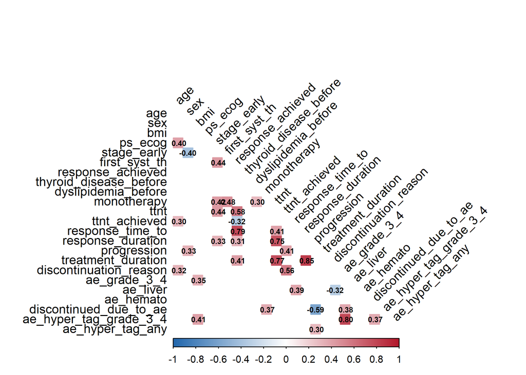

```r
num_cols <- names(df)[sapply(df, is.numeric)]
if (length(num_cols) >= 2) {
  r <- suppressWarnings(cor(df[num_cols], use = "pairwise.complete.obs", method = "spearman"))
  # Compute p-value matrix: prefer Hmisc::rcorr, else pairwise cor.test fallback
  if (requireNamespace("Hmisc", quietly = TRUE)) {
    rc <- Hmisc::rcorr(as.matrix(df[num_cols]), type = "spearman")
    r <- rc$r; p <- rc$P
  } else {
    p <- matrix(NA_real_, nrow = ncol(r), ncol = ncol(r), dimnames = dimnames(r))
    for (i in seq_len(ncol(r))) {
      for (j in seq_len(ncol(r))) {
        if (i == j) { p[i, j] <- NA_real_; next }
        x <- df[[ num_cols[i] ]]; y <- df[[ num_cols[j] ]]
        ok <- is.finite(x) & is.finite(y)
        if (sum(ok) >= 3) {
          p[i, j] <- tryCatch(stats::cor.test(x[ok], y[ok], method = "spearman", exact = FALSE)$p.value, error = function(e) NA_real_)
        } else {
          p[i, j] <- NA_real_
        }
      }
    }
  }
  # Tidy table of pairs (top 15 by |rho|)
  rn <- rownames(r); cn <- colnames(r)
  pairs <- expand.grid(var1 = rn, var2 = cn, stringsAsFactors = FALSE)
  pairs <- pairs[pairs$var1 < pairs$var2, ]
  eda_corr_tbl <- dplyr::mutate(pairs,
    rho = mapply(function(a,b) r[a,b], var1, var2),
    p   = mapply(function(a,b) p[a,b], var1, var2)
  )
  top <- eda_corr_tbl |>
    dplyr::filter(is.finite(rho)) |>
    dplyr::arrange(dplyr::desc(abs(rho))) |>
    dplyr::slice_head(n = 15)
  knitr::kable(top, digits = 3, col.names = c("Variable 1","Variable 2","Spearman rho","p-value")) %>%
    kableExtra::kable_styling(full_width = FALSE, bootstrap_options = c("striped","hover","condensed","responsive"))

  # Correlation heatmap with coefficients only for significant cells
  if (requireNamespace("corrplot", quietly = TRUE)) {
    r_plot <- r; sig <- !is.na(p) & p < 0.05
    r_plot[!sig] <- NA_real_
    corrplot::corrplot(r_plot, method = "color", type = "lower",
                       tl.col = "black", tl.srt = 45,
                       col = colorRampPalette(c("#2166AC","white","#B2182B"))(200),
                       addCoef.col = "black", number.cex = 0.6, na.label = " ")
  } else {
    message("Package 'corrplot' not available; showing table only.")
  }
}
```

### 4.2.1 Significant correlations (p < 0.05)

```r
if (exists("eda_corr_tbl")) {
  sig <- eda_corr_tbl |>
    dplyr::filter(is.finite(rho), is.finite(p), p < 0.05) |>
    dplyr::arrange(dplyr::desc(abs(rho)))
  if (nrow(sig) > 0) {
    knitr::kable(sig, digits = 3,
                 col.names = c("Variable 1","Variable 2","Spearman rho","p-value")) %>%
      kableExtra::kable_styling(full_width = FALSE,
                                bootstrap_options = c("striped","hover","condensed","responsive"))
  } else {
    cat("No significant pairwise correlations at alpha = 0.05.\n")
  }
}
```

| Variable 1 | Variable 2 | Spearman rho | p-value |
| --- | --- | --- | --- |
| response_duration | treatment_duration | 0.845 | 0.000 |
| ae_grade_3_4 | ae_hyper_tag_grade_3_4 | 0.799 | 0.000 |
| response_achieved | response_time_to | 0.788 | 0.000 |
| treatment_duration | ttnt | 0.767 | 0.000 |
| response_duration | ttnt | 0.748 | 0.000 |
| discontinued_due_to_ae | progression | -0.590 | 0.000 |
| response_achieved | ttnt | 0.581 | 0.000 |
| discontinuation_reason | ttnt_achieved | 0.564 | 0.000 |
| first_syst_th | monotherapy | 0.477 | 0.001 |
| first_syst_th | stage_early | 0.439 | 0.003 |
| stage_early | ttnt | 0.435 | 0.004 |
| monotherapy | stage_early | 0.421 | 0.004 |
| response_achieved | treatment_duration | 0.412 | 0.005 |
| progression | ttnt_achieved | 0.410 | 0.006 |
| ae_hyper_tag_grade_3_4 | bmi | 0.409 | 0.005 |
| response_time_to | ttnt | 0.405 | 0.006 |
| age | ps_ecog | 0.402 | 0.006 |
| sex | stage_early | -0.396 | 0.008 |
| ae_liver | response_time_to | 0.388 | 0.009 |
| ae_grade_3_4 | discontinued_due_to_ae | 0.376 | 0.031 |
| discontinued_due_to_ae | monotherapy | 0.368 | 0.035 |
| ae_hyper_tag_grade_3_4 | discontinued_due_to_ae | 0.368 | 0.035 |
| ae_grade_3_4 | bmi | 0.346 | 0.020 |
| response_duration | stage_early | 0.333 | 0.029 |
| progression | sex | 0.332 | 0.028 |
| age | discontinuation_reason | 0.321 | 0.034 |
| response_achieved | ttnt_achieved | -0.319 | 0.035 |
| ae_liver | discontinuation_reason | -0.316 | 0.036 |
| response_achieved | response_duration | 0.311 | 0.042 |
| dyslipidemia_before | monotherapy | 0.303 | 0.043 |
| ae_hyper_tag_any | progression | 0.302 | 0.046 |
| age | ttnt_achieved | 0.301 | 0.045 |

```r
if (exists("eda_corr_tbl")) {
  sig <- eda_corr_tbl |>
    dplyr::filter(is.finite(rho), is.finite(p), p < 0.05) |>
    dplyr::arrange(dplyr::desc(abs(rho)))
  k <- if (exists("num_cols")) length(num_cols) else length(unique(c(eda_corr_tbl$var1, eda_corr_tbl$var2)))
  if (nrow(sig) > 0) {
    fmt <- function(v1, v2, r, p) {
      ptxt <- ifelse(p < 0.001, "p < 0.001", paste0("p = ", sprintf("%.3f", p)))
      paste0(v1, " – ", v2, " (", "\u03C1 = ", sprintf("%.2f", r), ", ", ptxt, ")")
    }
    items <- mapply(fmt, sig$var1, sig$var2, sig$rho, sig$p, USE.NAMES = FALSE)
    pairs_text <- paste(items, collapse = "; ")
    cat(sprintf(
      "We analyzed %d numeric variables. Significant pairwise correlations (Spearman, alpha = 0.05; unadjusted p-values): %d. Significant associations: %s.\n",
      k, nrow(sig), pairs_text
    ))
  } else {
    cat(sprintf(
      "We analyzed %d numeric variables. No significant pairwise correlations were detected (Spearman, alpha = 0.05).\n",
      k
    ))
  }
}
```

We analyzed 23 numeric variables. Significant pairwise correlations (Spearman, alpha = 0.05; unadjusted p-values): 32. Significant associations: response_duration – treatment_duration (ρ = 0.85, p < 0.001); ae_grade_3_4 – ae_hyper_tag_grade_3_4 (ρ = 0.80, p < 0.001); response_achieved – response_time_to (ρ = 0.79, p < 0.001); treatment_duration – ttnt (ρ = 0.77, p < 0.001); response_duration – ttnt (ρ = 0.75, p < 0.001); discontinued_due_to_ae – progression (ρ = -0.59, p < 0.001); response_achieved – ttnt (ρ = 0.58, p < 0.001); discontinuation_reason – ttnt_achieved (ρ = 0.56, p < 0.001); first_syst_th – monotherapy (ρ = 0.48, p < 0.001); first_syst_th – stage_early (ρ = 0.44, p = 0.003); stage_early – ttnt (ρ = 0.44, p = 0.004); monotherapy – stage_early (ρ = 0.42, p = 0.004); response_achieved – treatment_duration (ρ = 0.41, p = 0.005); progression – ttnt_achieved (ρ = 0.41, p = 0.006); ae_hyper_tag_grade_3_4 – bmi (ρ = 0.41, p = 0.005); response_time_to – ttnt (ρ = 0.41, p = 0.006); age – ps_ecog (ρ = 0.40, p = 0.006); sex – stage_early (ρ = -0.40, p = 0.008); ae_liver – response_time_to (ρ = 0.39, p = 0.009); ae_grade_3_4 – discontinued_due_to_ae (ρ = 0.38, p = 0.031); discontinued_due_to_ae – monotherapy (ρ = 0.37, p = 0.035); ae_hyper_tag_grade_3_4 – discontinued_due_to_ae (ρ = 0.37, p = 0.035); ae_grade_3_4 – bmi (ρ = 0.35, p = 0.020); response_duration – stage_early (ρ = 0.33, p = 0.029); progression – sex (ρ = 0.33, p = 0.028); age – discontinuation_reason (ρ = 0.32, p = 0.034); response_achieved – ttnt_achieved (ρ = -0.32, p = 0.035); ae_liver – discontinuation_reason (ρ = -0.32, p = 0.036); response_achieved – response_duration (ρ = 0.31, p = 0.042); dyslipidemia_before – monotherapy (ρ = 0.30, p = 0.043); ae_hyper_tag_any – progression (ρ = 0.30, p = 0.046); age – ttnt_achieved (ρ = 0.30, p = 0.045).

## 4.3 Factor vs stage_early tests

Goal: assess association between each categorical variable (factors or 0/1/NA) and `stage_early`. Use Pearson’s chi-square when expected counts are adequate; otherwise Fisher’s exact test. Results are shown inline as a table (no files saved).

```r
# Resolve stage column robustly and coerce to factor (ref = "0" if present)
col_stage <- resolve_col(df, "stage_early", alias_map$stage_early)
stage <- df[[col_stage]]
if (is.numeric(stage) || is.logical(stage)) stage <- factor(stage)
if (is.factor(stage) && "0" %in% levels(stage)) stage <- stats::relevel(stage, ref = "0")

is_binary01 <- function(x) {
  ux <- unique(x[!is.na(x)])
  if (length(ux) == 0) return(FALSE)
  if (is.logical(x)) return(TRUE)
  if (is.numeric(x)) return(all(ux %in% c(0,1)))
  FALSE
}

is_small_factor <- function(x, max_levels = 10) {
  if (is.factor(x)) return(nlevels(x) <= max_levels)
  if (is.character(x)) return(dplyr::n_distinct(x[!is.na(x)]) <= max_levels)
  FALSE
}

candidate_vars <- setdiff(names(df), col_stage)
keep <- purrr::keep(candidate_vars, function(v){
  x <- df[[v]]
  is_binary01(x) || is_small_factor(x)
})

analyze_var <- function(vname) {
  x <- df[[vname]]
  # Coerce to factor appropriately
  if (is_binary01(x)) {
    x <- factor(if (is.logical(x)) as.integer(x) else as.integer(x))
  } else if (is.character(x)) {
    x <- factor(x)
  }
  d <- dplyr::tibble(x = x, stage = stage) |> tidyr::drop_na()
  if (!nrow(d)) return(dplyr::tibble(feature = vname, levels_n = NA_integer_, test = NA_character_, statistic = NA_real_, p_value = NA_real_, expected_min = NA_real_))
  tab <- table(d$x, d$stage)
  # Expected counts
  rs <- rowSums(tab); cs <- colSums(tab); n <- sum(tab)
  expected <- outer(rs, cs, FUN = function(a,b) a*b/n)
  exp_min <- suppressWarnings(min(expected))
  use_fisher <- any(expected < 5, na.rm = TRUE) || any(tab == 0)
  if (use_fisher) {
    ft <- tryCatch(stats::fisher.test(tab), error = function(e) NULL)
    p <- if (!is.null(ft)) ft$p.value else NA_real_
    stat <- NA_real_
    tst <- "Fisher"
  } else {
    ct <- tryCatch(stats::chisq.test(tab, correct = FALSE), error = function(e) NULL)
    p <- if (!is.null(ct)) ct$p.value else NA_real_
    stat <- if (!is.null(ct)) unname(ct$statistic) else NA_real_
    tst <- "Chi-square"
  }
  dplyr::tibble(feature = vname, levels_n = nrow(tab), test = tst, statistic = stat, p_value = p, expected_min = exp_min)
}

res <- purrr::map_dfr(keep, analyze_var) |>
  dplyr::arrange(p_value)

knitr::kable(res, digits = 4, col.names = c("Feature","Levels","Test","Statistic","p-value","Min expected")) %>%
  kableExtra::kable_styling(full_width = FALSE, bootstrap_options = c("striped","hover","condensed","responsive"))
```

| Feature | Levels | Test | Statistic | p-value | Min expected |
| --- | --- | --- | --- | --- | --- |
| monotherapy | 2 | Fisher |  | 0.0092 | 2.7045 |
| sex | 2 | Fisher |  | 0.0134 | 2.8636 |
| first_syst_th | 2 | Fisher |  | 0.0140 | 1.2727 |
| discontinuation_reason | 2 | Fisher |  | 0.1628 | 1.7907 |
| ae_hyper_tag_grade_3_4 | 2 | Fisher |  | 0.2204 | 2.7045 |
| ps_ecog | 2 | Fisher |  | 0.4013 | 2.2273 |
| ae_grade_3_4 | 2 | Fisher |  | 0.4121 | 3.5000 |
| ttnt_achieved | 2 | Fisher |  | 0.6188 | 1.4318 |
| dyslipidemia_before | 2 | Fisher |  | 0.6594 | 1.7500 |
| response_achieved | 2 | Fisher |  | 0.6845 | 2.7674 |
| ae_hyper_tag_any | 2 | Fisher |  | 1.0000 | 0.7955 |
| thyroid_disease_before | 2 | Fisher |  | 1.0000 | 0.7955 |
| progression | 2 | Fisher |  | 1.0000 | 3.4186 |
| ae_liver | 2 | Fisher |  | 1.0000 | 2.0682 |
| ae_hemato | 2 | Fisher |  | 1.0000 | 0.9545 |
| discontinued_due_to_ae | 2 | Fisher |  | 1.0000 | 1.9688 |

```r
if (exists("res") && is.data.frame(res)) {
  n_total  <- sum(is.finite(res$p_value))
  n_fisher <- sum(res$test == "Fisher", na.rm = TRUE)
  n_chi    <- sum(res$test == "Chi-square", na.rm = TRUE)
  n_sig    <- sum(is.finite(res$p_value) & res$p_value < 0.05)

  cat(sprintf(
    "We tested associations between categorical features and stage_early using Pearson's chi-square when expected cell counts were adequate, and Fisher's exact test otherwise. In total, %d features were evaluated (%d by chi-square, %d by Fisher).\n",
    n_total, n_chi, n_fisher
  ))

  cat("Choice of test. Fisher's exact test was used when any expected count was < 5 or when a contingency cell had zero counts; otherwise Pearson's chi-square test was applied. In the table, 'Min expected' shows the minimum expected frequency across cells; low values indicate that Fisher's test is more appropriate. The 'Statistic' column is the chi-square statistic (NA for Fisher). The 'p-value' column reports the test p-value.\n")

  if (n_sig > 0) {
    cat(sprintf(
      "Interpretation. We observed %d features with p < 0.05. A significant p-value indicates statistical evidence of association between the feature and stage_early (unadjusted, descriptive). It does not imply causality, and multiple testing was not adjusted; results should be interpreted in clinical context.\n",
      n_sig
    ))
  } else {
    cat("Interpretation. No features showed p < 0.05; we did not find statistical evidence of association between these categorical features and stage_early at the 0.05 level (unadjusted).\n")
  }
}
```

We tested associations between categorical features and stage_early using Pearson’s chi-square when expected cell counts were adequate, and Fisher’s exact test otherwise. In total, 16 features were evaluated (0 by chi-square, 16 by Fisher). Choice of test. Fisher’s exact test was used when any expected count was < 5 or when a contingency cell had zero counts; otherwise Pearson’s chi-square test was applied. In the table, ‘Min expected’ shows the minimum expected frequency across cells; low values indicate that Fisher’s test is more appropriate. The ‘Statistic’ column is the chi-square statistic (NA for Fisher). The ‘p-value’ column reports the test p-value. Interpretation. We observed 3 features with p < 0.05. A significant p-value indicates statistical evidence of association between the feature and stage_early (unadjusted, descriptive). It does not imply causality, and multiple testing was not adjusted; results should be interpreted in clinical context.

```r
# Easystats-like narrative for significant associations (p < 0.05)
fmt_p_txt <- function(p) ifelse(is.na(p), "p = NA", ifelse(p < 0.001, "p < 0.001", paste0("p = ", sprintf("%.3f", p))))

sig_feats <- try(res |> dplyr::filter(is.finite(p_value), p_value < 0.05) |> dplyr::pull(feature), silent = TRUE)
if (!inherits(sig_feats, "try-error") && length(sig_feats)) {
  for (vname in sig_feats) {
    x <- df[[vname]]
    # Coerce as in the test step
    if (is.logical(x)) x <- as.integer(x)
    if (is.numeric(x) && all(na.omit(unique(x)) %in% c(0,1))) x <- factor(as.integer(x))
    if (is.character(x)) x <- factor(x)
    d <- dplyr::tibble(x = x, stage = stage) |> tidyr::drop_na()
    if (!nrow(d)) next
    tab <- table(d$x, d$stage)
    # Choose test and compute (again, now capturing df where available)
    rs <- rowSums(tab); cs <- colSums(tab); n <- sum(tab)
    expected <- outer(rs, cs, FUN = function(a,b) a*b/n)
    use_fisher <- any(expected < 5, na.rm = TRUE) || any(tab == 0)
    if (use_fisher) {
      ft <- tryCatch(stats::fisher.test(tab), error = function(e) NULL)
      stat_txt <- "Fisher's exact test"
      p_txt <- if (!is.null(ft)) fmt_p_txt(ft$p.value) else "p = NA"
    } else {
      ct <- tryCatch(stats::chisq.test(tab, correct = FALSE), error = function(e) NULL)
      df_txt <- if (!is.null(ct)) paste0("df = ", unname(ct$parameter)) else "df = NA"
      stat_val <- if (!is.null(ct)) unname(ct$statistic) else NA_real_
      stat_txt <- paste0("chi-square (", df_txt, ") = ", ifelse(is.finite(stat_val), sprintf("%.2f", stat_val), "NA"))
      p_txt <- if (!is.null(ct)) fmt_p_txt(ct$p.value) else "p = NA"
    }
    # Quick direction insight: for binary x, report proportions by stage; else show most different level
    dir_txt <- NULL
    if (nrow(tab) == 2) {
      prop_by_stage <- prop.table(tab, margin = 2)
      cols <- colnames(prop_by_stage)
      idx0 <- if ("0" %in% cols) which(cols=="0") else 1
      idx1 <- if ("1" %in% cols) which(cols=="1") else min(2, ncol(prop_by_stage))
      p1 <- prop_by_stage[2, idx1]; p0 <- prop_by_stage[2, idx0]
      dir_txt <- paste0(
        "Proportion of '", rownames(prop_by_stage)[2], "' by stage: ",
        "stage_early = 0: ", sprintf("%.1f%%", 100*p0), ", stage_early = 1: ", sprintf("%.1f%%", 100*p1), "."
      )
    } else if (nrow(tab) > 2) {
      prop_by_stage <- prop.table(tab, margin = 2)
      cols <- colnames(prop_by_stage)
      idx0 <- if ("0" %in% cols) which(cols=="0") else 1
      idx1 <- if ("1" %in% cols) which(cols=="1") else min(2, ncol(prop_by_stage))
      diffs <- abs(prop_by_stage[, idx1] - prop_by_stage[, idx0])
      lvl <- names(which.max(diffs))
      dir_txt <- paste0(
        "Largest shift observed for level '", lvl, "' (",
        sprintf("%.1f%%", 100*prop_by_stage[lvl, idx0]), " vs ", sprintf("%.1f%%", 100*prop_by_stage[lvl, idx1]), ")."
      )
    }
    cat(paste0("- ", vname, ": significant association with stage_early (", stat_txt, ", ", p_txt, "). ", ifelse(is.null(dir_txt), "", dir_txt), "\n"))
  }
} else {
  cat("No significant categorical associations to report (p < 0.05).\n")
}
```

- monotherapy: significant association with stage_early (Fisher’s exact test, p = 0.009). Proportion of ‘1’ by stage: stage_early = 0: 29.7%, stage_early = 1: 85.7%.
- sex: significant association with stage_early (Fisher’s exact test, p = 0.013). Proportion of ‘1’ by stage: stage_early = 0: 67.6%, stage_early = 1: 14.3%.
- first_syst_th: significant association with stage_early (Fisher’s exact test, p = 0.014). Proportion of ‘1’ by stage: stage_early = 0: 10.8%, stage_early = 1: 57.1%.

# 5 Statistics

## 5.1 Main models

### 5.1.1 Logistic results

**The model equation:**

$$\log\frac{\Pr(\text{Response achieved}=1)}{\Pr(\text{Response
achieved}=0)}
= \beta_0 + \beta_1\,\mathrm{(\text{Stage Early})}$$

Where: beta_0 is the intercept (log-odds when stage_early = 0). beta_1 is the log-odds ratio for stage_early = 1 vs 0; the odds ratio is OR = exp(beta_1).

```r
log_res <- try(render_logistic_results(df, alias_map), silent = TRUE)
if (!inherits(log_res, "try-error") && !is.null(log_res$table)) {
  knitr::kable(log_res$table, col.names = c("outcome","OR","95% CI","p","stage_early=0 prob","95% CI","stage_early=1 prob","95% CI")) %>%
    kableExtra::kable_styling(full_width = FALSE, bootstrap_options = c("striped","hover","condensed","responsive"))
}
```

| outcome | OR | 95% CI | p | stage_early=0 prob | 95% CI | stage_early=1 prob | 95% CI |
| --- | --- | --- | --- | --- | --- | --- | --- |
| response_achieved | 1.79 | [0.33, 13.65] | 0.521 | 0.58 | [0.42, 0.73] | 0.71 | [0.33, 0.93] |

We modeled response_achieved using logistic regression with stage_early as the predictor. In all patients, the effect of stage_early (1 vs 0) was OR = 1.79 (95% CI [0.33, 13.65], p = 0.521). Estimated response probabilities by stage: stage_early = 0: 0.58 (95% CI [0.42, 0.73]); stage_early = 1: 0.71 (95% CI [0.33, 0.93]).

### 5.1.2 Survival analyses

**The model equation:**

$$h(t \,|\, \mathrm{\text{Stage Early}}) =
h_0(t)\,\exp\!\big(\beta_1\,\mathrm{\text{Stage Early}}\big)$$

Where: h(t) is the hazard at time t; h0(t) is the baseline hazard (for stage_early = 0). beta_1 is the log-hazard ratio for stage_early = 1 vs 0; the hazard ratio is HR = exp(beta_1).

```r
# Resolve needed columns via alias map
col_stage <- resolve_col(df, "stage_early", alias_map$stage_early)
col_time_ttnt <- resolve_col(df, "time_to_next_treatmen", alias_map$time_to_next_treatmen)
col_event_ttnt <- resolve_col(df, "ttnt_achieved", alias_map$ttnt_achieved)
col_treat_duration <- resolve_col(df, "treatment_duration", alias_map$treatment_duration)
col_event_discont <- resolve_col(df, "discontinuation_reason", alias_map$discontinuation_reason)
col_response_duration <- resolve_col(df, "response_duration", alias_map$response_duration)
col_event_progression <- resolve_col(df, "progression", alias_map$progression)

km_specs <- list(
  list(label = "time_to_next_treatment", time = col_time_ttnt, event = col_event_ttnt),
  list(label = "treatment_duration",     time = col_treat_duration, event = col_event_discont),
  list(label = "response_duration",      time = col_response_duration, event = col_event_progression)
)

cox_main <- purrr::map_dfr(km_specs, function(sp) {
  survival_stats_for(df, time_col = sp$time, event_col = sp$event, stage_col = col_stage, label = sp$label)
})

if (nrow(cox_main) > 0) {
  tbl_main_surv <- cox_main |>
    dplyr::transmute(outcome,
                     HR = sprintf("%.2f", estimate),
                     `95% CI` = sprintf("[%.2f, %.2f]", conf.low, conf.high),
                     p = ifelse(p.value < 0.001, "<0.001", sprintf("%.3f", p.value)),
                     `median (stage_early=0)` = ifelse(is.finite(median_stage0), sprintf("%.2f", median_stage0), NA_character_),
                     `95% CI (0)` = median_stage0_ci,
                     `median (stage_early=1)` = ifelse(is.finite(median_stage1), sprintf("%.2f", median_stage1), NA_character_),
                     `95% CI (1)` = median_stage1_ci)

  knitr::kable(tbl_main_surv,
               col.names = c("outcome","HR","95% CI","p","median (stage_early=0)","95% CI","median (stage_early=1)","95% CI")) %>%
    kableExtra::kable_styling(full_width = FALSE, bootstrap_options = c("striped","hover","condensed","responsive")) %>%
    kableExtra::collapse_rows(columns = 1, valign = "top")
}
```

| outcome | HR | 95% CI | p | median (stage_early=0) | 95% CI | median (stage_early=1) | 95% CI |
| --- | --- | --- | --- | --- | --- | --- | --- |
| time_to_next_treatment | 0.26 | [0.08, 0.80] | 0.018 | 6.00 | [5.00, 18.00] | 44.00 | [22.00, NA] |
| treatment_duration | 1.06 | [0.45, 2.48] | 0.890 | 13.00 | [8.00, 46.00] | 35.00 | [22.00, NA] |
| response_duration | 0.46 | [0.13, 1.59] | 0.220 | 16.00 | [8.00, NA] | 40.00 | [15.00, NA] |

We fitted Cox proportional hazards models for survival endpoints with stage_early as the predictor. Across outcomes: time_to_next_treatment: HR = 0.26 (95% CI [0.08, 0.80], p = 0.018); KM medians stage_early = 0: 6.00 [5.00, 18.00]; stage_early = 1: 44.00 [22.00, NA]. treatment_duration: HR = 1.06 (95% CI [0.45, 2.48], p = 0.890); KM medians stage_early = 0: 13.00 [8.00, 46.00]; stage_early = 1: 35.00 [22.00, NA]. response_duration: HR = 0.46 (95% CI [0.13, 1.59], p = 0.220); KM medians stage_early = 0: 16.00 [8.00, NA]; stage_early = 1: 40.00 [15.00, NA].

### 5.1.3 Linear results

**The model equation:**

$$\text{Time to response} = \beta_0 + \beta_1\,\mathrm{\text{Stage Early}}
+ \varepsilon, \quad \varepsilon \sim \mathcal{N}(0,\sigma^2)$$

Where: beta_0 is the expected value when stage_early = 0; beta_1 is the mean difference between stage_early = 1 and 0; epsilon is a random error with mean 0 and variance sigma^2.

```r
tbl_lin <- try(render_linear_results_table(df, alias_map), silent = TRUE)
if (!inherits(tbl_lin, "try-error") && !is.null(tbl_lin)) {
  knitr::kable(tbl_lin, col.names = c("outcome","mean diff (1-0)","95% CI","p","mean (stage_early=0)","95% CI","mean (stage_early=1)","95% CI")) %>%
    kableExtra::kable_styling(full_width = FALSE, bootstrap_options = c("striped","hover","condensed","responsive"))
}
```

| outcome | mean diff (1-0) | 95% CI | p | mean (stage_early=0) | 95% CI | mean (stage_early=1) | 95% CI |
| --- | --- | --- | --- | --- | --- | --- | --- |
| response_time_to | -1.24 | [-4.18, 1.69] | 0.392 | 4.04 | [2.80, 5.28] | 2.80 | [0.14, 5.46] |

We modeled response_time_to (restricted to y > 0) using linear regression with stage_early as the predictor. In all patients, the mean difference (1 vs 0) was -1.24 (95% CI [-4.18, 1.69], p = 0.392). Estimated means by stage: stage_early = 0: 4.04 (95% CI [2.80, 5.28]); stage_early = 1: 2.80 (95% CI [0.14, 5.46]).

### 5.1.4 Plots - main

#### Survival

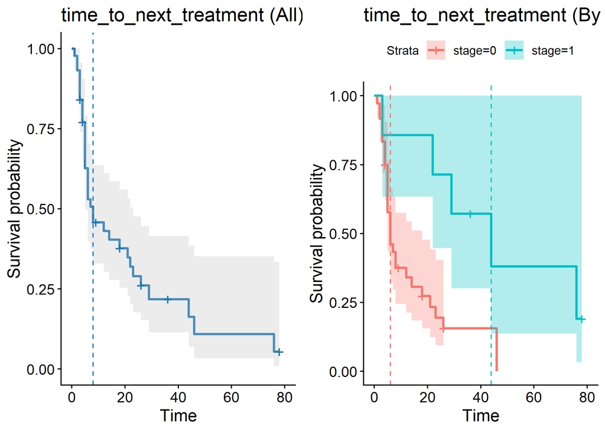

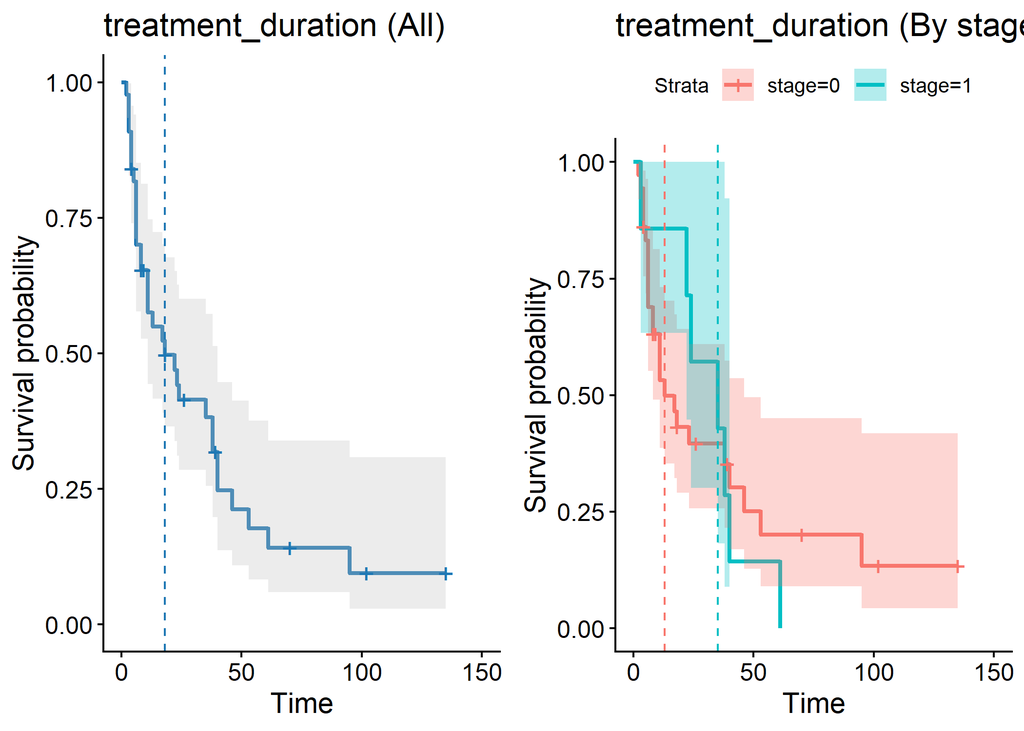

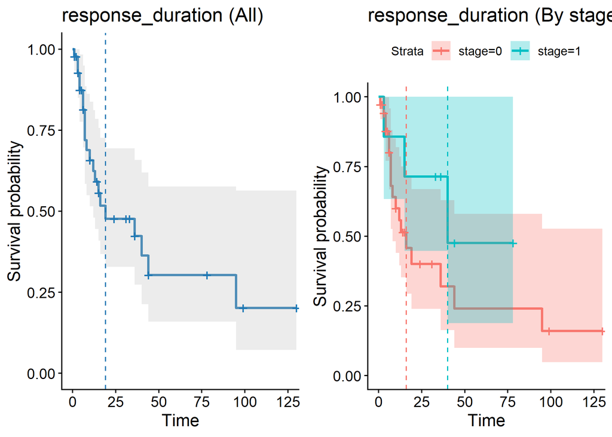

```r
# Inline KM figures for each survival outcome (All vs By stage)
if (exists("km_specs") && length(km_specs) > 0) {
  for (sp in km_specs) {
    d <- df |>
      dplyr::select(time = dplyr::all_of(sp$time),
                    event = dplyr::all_of(sp$event),
                    stage = dplyr::all_of(col_stage)) |>
      dplyr::mutate(
        time  = suppressWarnings(readr::parse_number(as.character(.data$time))),
        event = ensure_binary_event_local(.data$event),
        stage = as.factor(.data$stage)
      ) |>
      (\(d) if (identical(sp$label, "treatment_duration")) dplyr::mutate(d, event = dplyr::if_else(d$event == 0, 0L, 1L)) else d)() |>
      dplyr::filter(!is.na(time), !is.na(event))

    if (nrow(d) < 5) next

    # Overall
    f_all <- survival::survfit(survival::Surv(time, event) ~ 1, data = d)
    pal_all <- "#1f78b4"
    p_left <- survminer::ggsurvplot(f_all, data = d, conf.int = TRUE, legend = "none", palette = pal_all)$plot +
      ggplot2::ggtitle(paste0(sp$label, " (All)"))
    md_all <- try(survminer::surv_median(f_all), silent = TRUE)
    if (!inherits(md_all, "try-error") && isTRUE(is.finite(md_all$median[1])))
      p_left <- p_left + ggplot2::geom_vline(xintercept = md_all$median[1], linetype = "dashed", color = pal_all)

    # By stage
    f_by <- survival::survfit(survival::Surv(time, event) ~ stage, data = d)
    p_right_list <- survminer::ggsurvplot(f_by, data = d, conf.int = TRUE)
    p_right <- p_right_list$plot + ggplot2::ggtitle(paste0(sp$label, " (By stage)"))
    str_order <- unique(as.character(p_right$data$strata))
    pal <- scales::hue_pal()(length(str_order))
    p_right <- p_right + ggplot2::scale_color_manual(values = stats::setNames(pal, str_order))
    md_by <- try(survminer::surv_median(f_by), silent = TRUE)
    if (!inherits(md_by, "try-error")) {
      for (i in seq_along(str_order)) {
        v <- md_by$median[md_by$strata == str_order[i]]
        if (length(v) == 1 && is.finite(v))
          p_right <- p_right + ggplot2::geom_vline(xintercept = v, linetype = "dashed", color = pal[i])
      }
    }

    if (requireNamespace("cowplot", quietly = TRUE)) {
      print(cowplot::plot_grid(p_left, p_right, ncol = 2))
    } else {
      print(p_left); print(p_right)
    }
  }
}
```

#### Linear

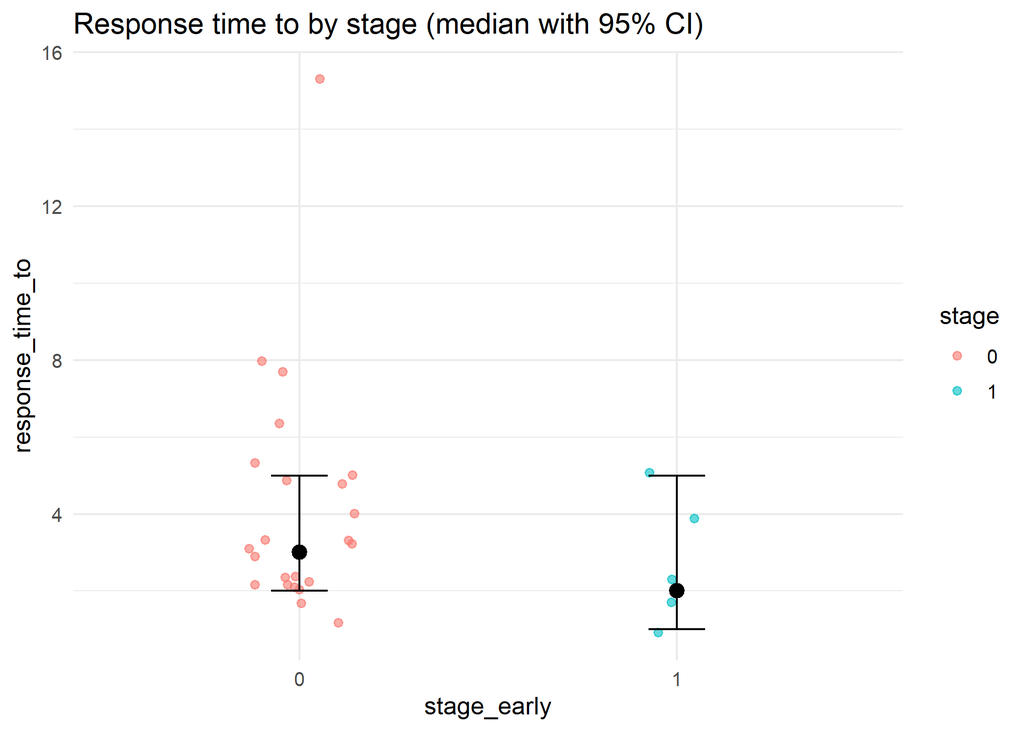

```r
# Jitter plot of response_time_to by stage with bootstrap median and 95% CI (5000x)
col_stage <- resolve_col(df, "stage_early", alias_map$stage_early)
col_response_time_to <- resolve_col(df, "response_time_to", alias_map$response_time_to)
d_lin <- df |>
  dplyr::select(y = dplyr::all_of(col_response_time_to), stage = dplyr::all_of(col_stage)) |>
  dplyr::filter(!is.na(y), !is.na(stage), y > 0) |>
  dplyr::mutate(stage = as.factor(stage))

boot_ci <- function(x, n = 5000L, conf = c(0.025, 0.975)) {
  x <- x[is.finite(x)]
  if (length(x) < 2) return(c(med = NA_real_, l = NA_real_, u = NA_real_))
  meds <- replicate(n, stats::median(sample(x, replace = TRUE)))
  c(med = stats::median(x), l = stats::quantile(meds, conf[1]), u = stats::quantile(meds, conf[2]))
}

if (nrow(d_lin) >= 2) {
  pal <- scales::hue_pal()(length(levels(d_lin$stage)))
  names(pal) <- levels(d_lin$stage)
  # Compute bootstrap CI by stage
  ci_df <- d_lin |>
    dplyr::group_by(stage) |>
    dplyr::summarise(
      med = stats::median(y, na.rm = TRUE),
      l = {
        meds <- replicate(5000L, stats::median(sample(y, replace = TRUE)))
        stats::quantile(meds, 0.025, names = FALSE)
      },
      u = {
        meds <- replicate(5000L, stats::median(sample(y, replace = TRUE)))
        stats::quantile(meds, 0.975, names = FALSE)
      },
      .groups = "drop"
    )

  p <- ggplot2::ggplot(d_lin, ggplot2::aes(x = stage, y = y, color = stage)) +
    ggplot2::geom_jitter(width = 0.15, alpha = 0.6, size = 1.7) +
    ggplot2::geom_errorbar(data = ci_df, ggplot2::aes(x = stage, ymin = l, ymax = u), width = 0.15, color = "black", inherit.aes = FALSE) +
    ggplot2::geom_point(data = ci_df, ggplot2::aes(x = stage, y = med), color = "black", size = 3, inherit.aes = FALSE) +
    ggplot2::scale_color_manual(values = pal) +
    ggplot2::labs(x = "stage_early", y = "response_time_to", title = "Response time to by stage (median with 95% CI)") +
    ggplot2::theme_minimal(base_size = 12)
  print(p)
}
```

#### Logistic

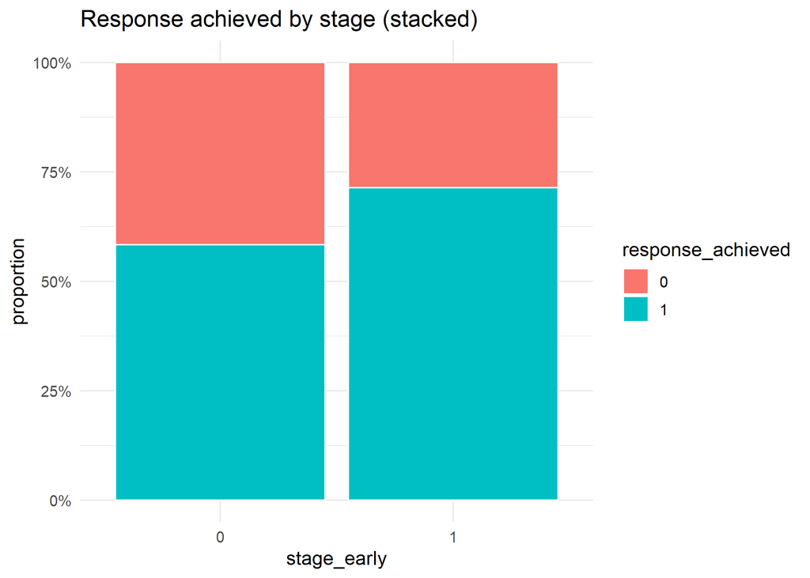

```r
# Stacked column chart: response_achieved by stage_early (proportion within stage)
col_stage <- resolve_col(df, "stage_early", alias_map$stage_early)
col_response_achieved <- resolve_col(df, "response_achieved", alias_map$response_achieved)
d_log <- df |>
  dplyr::select(y = dplyr::all_of(col_response_achieved), stage = dplyr::all_of(col_stage)) |>
  dplyr::filter(!is.na(y), !is.na(stage)) |>
  dplyr::mutate(stage = as.factor(stage), y = factor(y))

if (nrow(d_log) >= 1) {
  pal <- scales::hue_pal()(length(levels(d_log$y)))
  names(pal) <- levels(d_log$y)
  p <- ggplot2::ggplot(d_log, ggplot2::aes(x = stage, fill = y)) +
    ggplot2::geom_bar(position = "fill", color = "white") +
    ggplot2::scale_y_continuous(labels = scales::percent_format()) +
    ggplot2::scale_fill_manual(values = pal, name = "response_achieved") +
    ggplot2::labs(x = "stage_early", y = "proportion", title = "Response achieved by stage (stacked)") +
    ggplot2::theme_minimal(base_size = 12)
  print(p)
}
```

## 5.2 Adjusted models - Stage Early

### 5.2.1 Logistic results

**The model equation (adjusted):**

$$\log\left(\frac{\Pr(\text{Response achieved}=1)}{\Pr(\text{Response
achieved}=0)}\right)
= \beta_0 + \beta_1\,\text{Stage Early} + \beta_2\,\text{Covariate}$$

Where: beta_0 is the intercept (log-odds when stage_early = 0 and the covariate is at its reference/0), beta_1 is the log-odds ratio for stage_early = 1 vs 0 (holding the covariate fixed), and beta_2 is the covariate effect (for factors: contrast vs the reference level; for numeric covariates: effect per one-unit increase). Effects are reported on the OR scale: OR = exp(beta).

```r
# Helper: pick a reasonable contrast level for factors (mirrors earlier helpers)
pick_contrast_level <- function(x) {
  xf <- as.factor(x)
  levs <- levels(xf)
  if (length(levs) <= 1) return(NULL)
  ref <- levs[1]
  cand <- levs[levs != ref]
  if (!length(cand)) return(NULL)
  if ("1" %in% cand) return("1")
  cl <- tolower(cand)
  if (any(cl == "yes")) return(cand[which(cl == "yes")[1]])
  tab <- sort(table(xf[xf != ref]), decreasing = TRUE)
  if (length(tab)) return(names(tab)[1])
  cand[1]
}

coerce_predictor <- function(x) {
  if (is.factor(x)) return(x)
  if (is.character(x)) return(factor(x))
  if (is.logical(x)) return(factor(as.integer(x)))
  # leave numeric as is
  x
}

resolve_or_identity <- function(df, nm) {
  # Use resolve_col if alias exists; otherwise return name if present
  if (exists("alias_map")) {
    alias <- try(alias_map[[nm]], silent = TRUE)
    if (!inherits(alias, "try-error")) {
      hit <- try(resolve_col(df, nm, alias), silent = TRUE)
      if (!inherits(hit, "try-error") && is.character(hit) && length(hit) == 1) return(hit)
    }
  }
  if (nm %in% names(df)) return(nm)
  nm
}

fit_adj_logistic <- function(df, outcome_col, stage_col, covar_col) {
  d_mod <- df |>
    dplyr::select(y = dplyr::all_of(outcome_col), stage = dplyr::all_of(stage_col), x = dplyr::all_of(covar_col)) |>
    dplyr::mutate(y = as.factor(y), x = coerce_predictor(x)) |>
    dplyr::filter(!is.na(y), !is.na(stage), !is.na(x))
  if (nrow(d_mod) == 0 || length(unique(d_mod$stage)) < 2) return(NULL)
  m_all <- tryCatch(stats::glm(y ~ stage + x, data = d_mod, family = stats::binomial()), error = function(e) NULL)
  if (is.null(m_all)) return(NULL)
  tt <- broom::tidy(m_all, conf.int = TRUE, exponentiate = TRUE)
  # stage term: prefer term that contains 'stage'
  st <- tt |>
    dplyr::filter(stringr::str_detect(.data$term, "^stage")) |>
    dplyr::slice(1)
  # covariate term: if factor, pick one contrast level
  cv_row <- NULL
  if (is.factor(d_mod$x)) {
    lab <- pick_contrast_level(d_mod$x)
    if (is.null(lab)) {
      cv_row <- tt |> dplyr::filter(stringr::str_starts(.data$term, "x")) |> dplyr::slice(1)
    } else {
      # term will look like 'xLEVEL'
      cv_row <- tt |> dplyr::filter(.data$term == paste0("x", lab)) |> dplyr::slice(1)
      if (nrow(cv_row) == 0) cv_row <- tt |> dplyr::filter(stringr::str_starts(.data$term, "x")) |> dplyr::slice(1)
    }
  } else {
    cv_row <- tt |> dplyr::filter(.data$term == "x") |> dplyr::slice(1)
  }
  if (nrow(st) == 0 || nrow(cv_row) == 0) return(NULL)
  tibble::tibble(
    `estimate (stage_early)` = st$estimate,
    `p-value (stage_early)` = st$p.value,
    `95%CI (stage_early)` = sprintf("[%.2f, %.2f]", st$conf.low, st$conf.high),
    `estimate (covariate)` = cv_row$estimate,
    `p-value (covariate)` = cv_row$p.value,
    `95%CI (covariate)` = sprintf("[%.2f, %.2f]", cv_row$conf.low, cv_row$conf.high)
  )
}

col_stage <- resolve_or_identity(df, "stage_early")
col_y     <- resolve_or_identity(df, "response_achieved")
covars <- c("age","sex","bmi","ps_ecog","first_syst_th","monotherapy","ae_grade_3_4")
covars <- covars[covars %in% names(df)]

adj_spec <- tidyr::expand_grid(Outcomes = col_y, Covariate = covars) |>
  dplyr::mutate(results = purrr::map(Covariate, ~ fit_adj_logistic(df, outcome_col = col_y, stage_col = col_stage, covar_col = .x))) |>
  dplyr::filter(!purrr::map_lgl(results, is.null)) |>
  tidyr::unnest(results)

if (nrow(adj_spec) > 0) {
  # Optional formatting for p-values
  fmt_p <- function(p) ifelse(is.na(p), NA_character_, ifelse(p < 0.001, "<0.001", sprintf("%.3f", p)))
  out_tbl <- adj_spec |>
    dplyr::mutate(
      `p-value (stage_early)` = fmt_p(`p-value (stage_early)`),
      `p-value (covariate)`   = fmt_p(`p-value (covariate)`)
    )
  knitr::kable(out_tbl, align = "l", col.names = c("Outcomes","Covariate","estimate (stage_early)","p-value (stage_early)","95%CI (stage_early)","estimate (covariate)","p-value (covariate)","95%CI (covariate)")) %>%
    kableExtra::kable_styling(full_width = FALSE, bootstrap_options = c("striped","hover","condensed","responsive"))
} else {
  cat("No adjusted logistic results available.\n")
}
```

| Outcomes | Covariate | estimate (stage_early) | p-value (stage_early) | 95%CI (stage_early) | estimate (covariate) | p-value (covariate) | 95%CI (covariate) |
| --- | --- | --- | --- | --- | --- | --- | --- |
| response_achieved | age | 1.734585 | 0.543 | [0.32, 13.32] | 0.9865449 | 0.608 | [0.93, 1.04] |
| response_achieved | sex | 1.916518 | 0.503 | [0.31, 16.34] | 1.1441346 | 0.844 | [0.29, 4.46] |
| response_achieved | bmi | 1.620715 | 0.597 | [0.29, 12.56] | 0.9418081 | 0.303 | [0.83, 1.05] |
| response_achieved | ps_ecog | 1.832680 | 0.507 | [0.34, 14.23] | 1.1452050 | 0.844 | [0.30, 4.68] |
| response_achieved | first_syst_th | 1.319101 | 0.780 | [0.19, 11.46] | 2.0146710 | 0.468 | [0.33, 17.33] |
| response_achieved | monotherapy | 1.366162 | 0.755 | [0.20, 11.99] | 1.5903622 | 0.528 | [0.39, 7.27] |
| response_achieved | ae_grade_3_4 | 2.089186 | 0.426 | [0.38, 16.65] | 1.8399535 | 0.346 | [0.53, 6.80] |

```r
# Stage-specific covariate effects (within-stage) via emmeans
if (!requireNamespace("emmeans", quietly = TRUE)) {
  cat("emmeans package not available; stage-wise covariate effects skipped.\n")
} else {
  fmt_p_str <- function(p) ifelse(is.na(p), NA_character_, ifelse(p < 0.001, "<0.001", sprintf("%.3f", p)))
  fmt_ci_str <- function(l, u) ifelse(is.na(l) | is.na(u), NA_character_, sprintf("[%.2f, %.2f]", l, u))

  compute_stagewise <- function(df, outcome_col, stage_col, covar_col) {
    safe_num <- function(x) {
      if (is.null(x) || length(x) < 1) return(NA_real_)
      y <- suppressWarnings(as.numeric(x[1]))
      if (length(y) < 1) return(NA_real_)
      y
    }
    d_mod <- df |>
      dplyr::select(y = dplyr::all_of(outcome_col), stage = dplyr::all_of(stage_col), x = dplyr::all_of(covar_col)) |>
      dplyr::mutate(y = as.factor(y), stage = as.factor(stage)) |>
      dplyr::filter(!is.na(y), !is.na(stage), !is.na(x))
    if (nrow(d_mod) == 0 || length(unique(d_mod$stage)) < 2) return(NULL)
    # Special handling for numeric age/bmi: report subgroup means instead of OR
    is_special_mean <- covar_col %in% c("age", "bmi")
    if (is_special_mean && is.numeric(d_mod$x)) {
      # compute bootstrap 95% CI for mean within each stage
      boot_mean_ci <- function(v, n = 2000L, conf = c(0.025, 0.975)) {
        v <- v[is.finite(v)]
        if (length(v) < 2) return(c(mean = mean(v), l = NA_real_, u = NA_real_))
        b <- replicate(n, mean(sample(v, replace = TRUE)))
        c(mean = mean(v), l = stats::quantile(b, conf[1], names = FALSE), u = stats::quantile(b, conf[2], names = FALSE))
      }
      st_levels <- levels(d_mod$stage)
      # Resolve stage labels robustly
      st_vals <- st_levels
      stage0_lab <- if (length(st_vals) >= 1) (if ("0" %in% st_vals) "0" else st_vals[1]) else NA_character_
      stage1_lab <- if (length(st_vals) >= 2) (if ("1" %in% st_vals) "1" else st_vals[2]) else NA_character_

      out <- tibble::tibble(
        `estimate (stage_early = 0)` = NA_real_,
        `p-value (stage_early = 0)` = NA_character_,
        `95%CI (stage_early = 0)` = NA_character_,
        `estimate (stage_early = 1)` = NA_real_,
        `p-value (stage_early = 1)` = NA_character_,
        `95%CI (stage_early = 1)` = NA_character_
      )
      if (!is.na(stage0_lab)) {
        v0 <- d_mod$x[as.character(d_mod$stage) == stage0_lab]
        ci0 <- boot_mean_ci(v0)
        out$`estimate (stage_early = 0)` <- ci0[["mean"]]
        out$`95%CI (stage_early = 0)` <- fmt_ci_str(ci0[["l"]], ci0[["u"]])
        # p-value: association within stage via logistic regression slope
        d0 <- d_mod[as.character(d_mod$stage) == stage0_lab, , drop = FALSE]
        p0 <- tryCatch({
          m0 <- stats::glm(y ~ x, data = d0, family = stats::binomial())
          as.numeric(broom::tidy(m0) |>
            dplyr::filter(.data$term == "x") |>
            dplyr::slice(1) |>
            dplyr::pull(.data$p.value))
        }, error = function(e) NA_real_)
        out$`p-value (stage_early = 0)` <- fmt_p_str(p0)
      }
      if (!is.na(stage1_lab)) {
        v1 <- d_mod$x[as.character(d_mod$stage) == stage1_lab]
        ci1 <- boot_mean_ci(v1)
        out$`estimate (stage_early = 1)` <- ci1[["mean"]]
        out$`95%CI (stage_early = 1)` <- fmt_ci_str(ci1[["l"]], ci1[["u"]])
        d1 <- d_mod[as.character(d_mod$stage) == stage1_lab, , drop = FALSE]
        p1 <- tryCatch({
          m1 <- stats::glm(y ~ x, data = d1, family = stats::binomial())
          as.numeric(broom::tidy(m1) |>
            dplyr::filter(.data$term == "x") |>
            dplyr::slice(1) |>
            dplyr::pull(.data$p.value))
        }, error = function(e) NA_real_)
        out$`p-value (stage_early = 1)` <- fmt_p_str(p1)
      }
      return(out)
    }

    # Default: fit interaction model and use emmeans/emtrends to report OR
    # Treat numeric binary (0/1) predictors as factors to obtain a clear 1 vs 0 OR
    if (is.numeric(d_mod$x)) {
      ux <- unique(d_mod$x[!is.na(d_mod$x)])
      if (length(ux) > 0 && all(ux %in% c(0,1))) {
        d_mod$x <- factor(as.integer(d_mod$x))
      }
    }
    d_mod <- d_mod |> dplyr::mutate(x = coerce_predictor(x))
    m_int <- tryCatch(stats::glm(y ~ stage * x, data = d_mod, family = stats::binomial()), error = function(e) NULL)
    if (is.null(m_int)) return(NULL)

    # Note: do NOT include 'outcomes' or 'covariates' here to avoid name collision on unnest
    out <- tibble::tibble(
      `estimate (stage_early = 0)` = NA_real_,
      `p-value (stage_early = 0)` = NA_character_,
      `95%CI (stage_early = 0)` = NA_character_,
      `estimate (stage_early = 1)` = NA_real_,
      `p-value (stage_early = 1)` = NA_character_,
      `95%CI (stage_early = 1)` = NA_character_
    )

    st_levels <- levels(d_mod$stage)

    if (is.factor(d_mod$x)) {
      em <- try(emmeans::emmeans(m_int, specs = ~ x | stage), silent = TRUE)
      if (!inherits(em, "try-error")) {
        cn <- try(emmeans::contrast(em, method = "trt.vs.ctrl", ref = 1), silent = TRUE)
        sm <- try(as.data.frame(summary(cn, infer = TRUE)), silent = TRUE)
        if (!inherits(sm, "try-error") && nrow(sm) > 0) {
          # Determine CI column names robustly
          lo_name <- if ("lower.CL" %in% names(sm)) "lower.CL" else if ("asymp.LCL" %in% names(sm)) "asymp.LCL" else NA_character_
          up_name <- if ("upper.CL" %in% names(sm)) "upper.CL" else if ("asymp.UCL" %in% names(sm)) "asymp.UCL" else NA_character_
          # Resolve stage labels present in summary
          st_vals <- if ("stage" %in% names(sm)) unique(as.character(sm$stage)) else levels(d_mod$stage)
          stage0_lab <- if (length(st_vals) >= 1) (if ("0" %in% st_vals) "0" else st_vals[1]) else NA_character_
          stage1_lab <- if (length(st_vals) >= 2) (if ("1" %in% st_vals) "1" else st_vals[2]) else NA_character_
          # Pick one contrast row per stage label
          if (!is.na(stage0_lab)) {
            r0 <- sm[as.character(sm$stage) == stage0_lab, , drop = FALSE]
            if (nrow(r0) >= 1) {
              est0 <- safe_num(r0$estimate)
              lo0  <- if (!is.na(lo_name)) safe_num(r0[[lo_name]]) else NA_real_
              up0  <- if (!is.na(up_name)) safe_num(r0[[up_name]]) else NA_real_
              p0v  <- safe_num(r0$p.value)
              out$`estimate (stage_early = 0)` <- ifelse(is.na(est0), NA_real_, exp(est0))
              out$`p-value (stage_early = 0)` <- fmt_p_str(p0v)
              out$`95%CI (stage_early = 0)` <- fmt_ci_str(ifelse(is.na(lo0), NA_real_, exp(lo0)), ifelse(is.na(up0), NA_real_, exp(up0)))
            }
          }
          if (!is.na(stage1_lab)) {
            r1 <- sm[as.character(sm$stage) == stage1_lab, , drop = FALSE]
            if (nrow(r1) >= 1) {
              est1 <- safe_num(r1$estimate)
              lo1  <- if (!is.na(lo_name)) safe_num(r1[[lo_name]]) else NA_real_
              up1  <- if (!is.na(up_name)) safe_num(r1[[up_name]]) else NA_real_
              p1v  <- safe_num(r1$p.value)
              out$`estimate (stage_early = 1)` <- ifelse(is.na(est1), NA_real_, exp(est1))
              out$`p-value (stage_early = 1)` <- fmt_p_str(p1v)
              out$`95%CI (stage_early = 1)` <- fmt_ci_str(ifelse(is.na(lo1), NA_real_, exp(lo1)), ifelse(is.na(up1), NA_real_, exp(up1)))
            }
          }
        }
      }
    } else {
      tr <- try(emmeans::emtrends(m_int, specs = ~ stage, var = "x"), silent = TRUE)
      if (!inherits(tr, "try-error")) {
        smt <- try(as.data.frame(summary(tr, infer = TRUE)), silent = TRUE)
        if (!inherits(smt, "try-error") && nrow(smt) > 0) {
          lo_name <- if ("lower.CL" %in% names(smt)) "lower.CL" else if ("asymp.LCL" %in% names(smt)) "asymp.LCL" else NA_character_
          up_name <- if ("upper.CL" %in% names(smt)) "upper.CL" else if ("asymp.UCL" %in% names(smt)) "asymp.UCL" else NA_character_
          trend_name <- if ("emtrends" %in% names(smt)) "emtrends" else if ("x.trend" %in% names(smt)) "x.trend" else if ("trend" %in% names(smt)) "trend" else NA_character_
          st_vals <- if ("stage" %in% names(smt)) unique(as.character(smt$stage)) else levels(d_mod$stage)
          stage0_lab <- if (length(st_vals) >= 1) (if ("0" %in% st_vals) "0" else st_vals[1]) else NA_character_
          stage1_lab <- if (length(st_vals) >= 2) (if ("1" %in% st_vals) "1" else st_vals[2]) else NA_character_
          if (!is.na(stage0_lab)) {
            r0 <- smt[as.character(smt$stage) == stage0_lab, , drop = FALSE]
            if (nrow(r0) >= 1) {
              est0 <- if (!is.na(trend_name)) safe_num(r0[[trend_name]]) else NA_real_
              lo0  <- if (!is.na(lo_name)) safe_num(r0[[lo_name]]) else NA_real_
              up0  <- if (!is.na(up_name)) safe_num(r0[[up_name]]) else NA_real_
              p0v  <- safe_num(r0$p.value)
              out$`estimate (stage_early = 0)` <- ifelse(is.na(est0), NA_real_, exp(est0))
              out$`p-value (stage_early = 0)` <- fmt_p_str(p0v)
              out$`95%CI (stage_early = 0)` <- fmt_ci_str(ifelse(is.na(lo0), NA_real_, exp(lo0)), ifelse(is.na(up0), NA_real_, exp(up0)))
            }
          }
          if (!is.na(stage1_lab)) {
            r1 <- smt[as.character(smt$stage) == stage1_lab, , drop = FALSE]
            if (nrow(r1) >= 1) {
              est1 <- if (!is.na(trend_name)) safe_num(r1[[trend_name]]) else NA_real_
              lo1  <- if (!is.na(lo_name)) safe_num(r1[[lo_name]]) else NA_real_
              up1  <- if (!is.na(up_name)) safe_num(r1[[up_name]]) else NA_real_
              p1v  <- safe_num(r1$p.value)
              out$`estimate (stage_early = 1)` <- ifelse(is.na(est1), NA_real_, exp(est1))
              out$`p-value (stage_early = 1)` <- fmt_p_str(p1v)
              out$`95%CI (stage_early = 1)` <- fmt_ci_str(ifelse(is.na(lo1), NA_real_, exp(lo1)), ifelse(is.na(up1), NA_real_, exp(up1)))
            }
          }
        }
      }
    }
    out
  }

  stagewise_tbl <- tidyr::expand_grid(outcomes = col_y, covariates = covars) |>
    dplyr::mutate(results = purrr::map(covariates, ~ compute_stagewise(df, outcome_col = col_y, stage_col = col_stage, covar_col = .x))) |>
    dplyr::filter(!purrr::map_lgl(results, is.null)) |>
    tidyr::unnest(results)

  if (nrow(stagewise_tbl) > 0) {
    # Round estimates to 3 decimals for display
    stagewise_disp <- stagewise_tbl |>
      dplyr::mutate(
        `estimate (stage_early = 0)` = ifelse(is.na(`estimate (stage_early = 0)`), NA_character_, sprintf("%.3f", as.numeric(`estimate (stage_early = 0)`))),
        `estimate (stage_early = 1)` = ifelse(is.na(`estimate (stage_early = 1)`), NA_character_, sprintf("%.3f", as.numeric(`estimate (stage_early = 1)`)))
      )
    knitr::kable(stagewise_disp, align = "l",
                 col.names = c(
                   "outcomes","covariates",
                   "estimate (stage_early = 0)","p-value (stage_early = 0)","95%CI (stage_early = 0)",
                   "estimate (stage_early = 1)","p-value (stage_early = 1)","95%CI (stage_early = 1)"
                 )) %>%
      kableExtra::kable_styling(full_width = FALSE, bootstrap_options = c("striped","hover","condensed","responsive")) %>%
      kableExtra::footnote(
        general = "This table evaluates the association of each covariate with the outcome within subgroups defined by stage_early (0 and 1) using a model with the stage × covariate interaction; estimates are subgroup-specific.",
        threeparttable = TRUE
      )
  } else {
    cat("No stage-wise covariate effects available.\n")
  }
}
```

| outcomes | covariates | estimate (stage_early = 0) | p-value (stage_early = 0) | 95%CI (stage_early = 0) | estimate (stage_early = 1) | p-value (stage_early = 1) | 95%CI (stage_early = 1) |
| --- | --- | --- | --- | --- | --- | --- | --- |
| response_achieved | age | 65.944 | 0.615 | [62.03, 69.75] | 63.429 | 0.895 | [52.86, 72.29] |
| response_achieved | sex | 1.000 | 1.000 | [0.25, 4.08] | 7825680.397 | 0.995 | [0.00, Inf] |
| response_achieved | bmi | 26.646 | 0.573 | [24.80, 28.54] | 24.900 | 0.301 | [21.73, 28.30] |
| response_achieved | ps_ecog | 1.000 | 1.000 | [0.25, 4.08] | 7825680.395 | 0.995 | [0.00, Inf] |
| response_achieved | first_syst_th | 0.684 | 0.721 | [0.09, 5.49] | 85089624.714 | 0.993 | [0.00, Inf] |
| response_achieved | monotherapy | 1.100 | 0.900 | [0.25, 4.86] | 78256803.939 | 0.994 | [0.00, Inf] |
| response_achieved | ae_grade_3_4 | 2.437 | 0.198 | [0.63, 9.47] | 0.250 | 0.442 | [0.01, 8.56] |

Note:  
This table evaluates the association of each covariate with the outcome within subgroups defined by stage_early (0 and 1) using a model with the stage × covariate interaction; estimates are subgroup-specific.

#### Plots - logistic

##### age

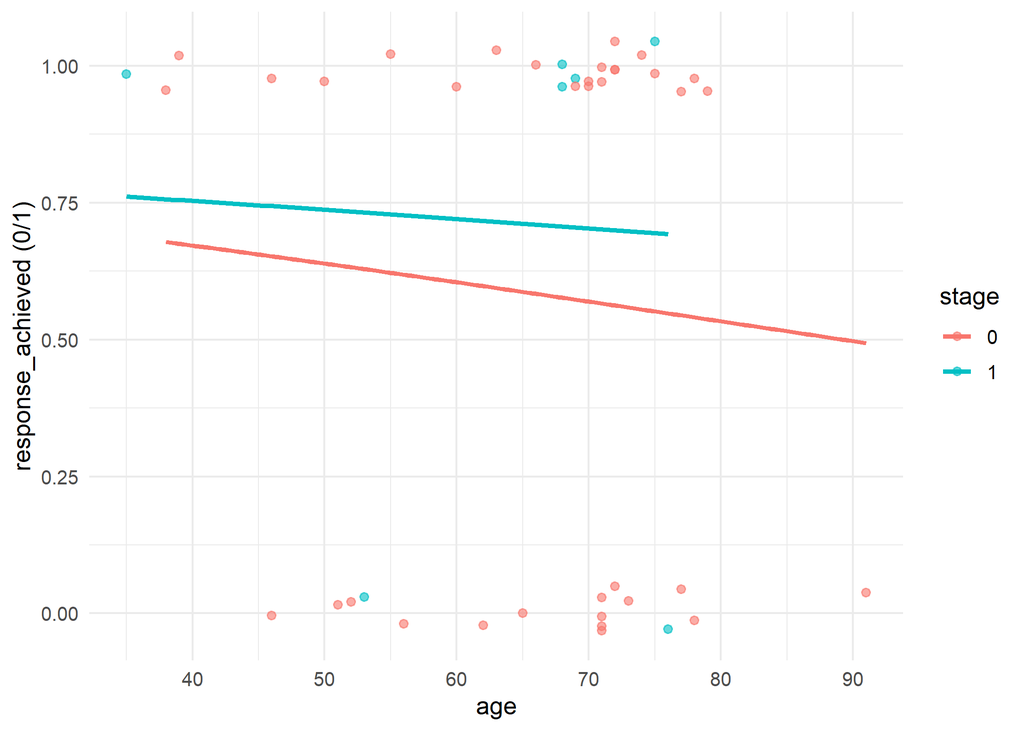

```r
p_age_adj <- try(plot_scatter_logit_adj(df, covar = resolve_or_identity(df, "age")), silent = TRUE)
if (!inherits(p_age_adj, "try-error") && !is.null(p_age_adj)) print(p_age_adj) else cat("No data for age.\n")
```

##### bmi

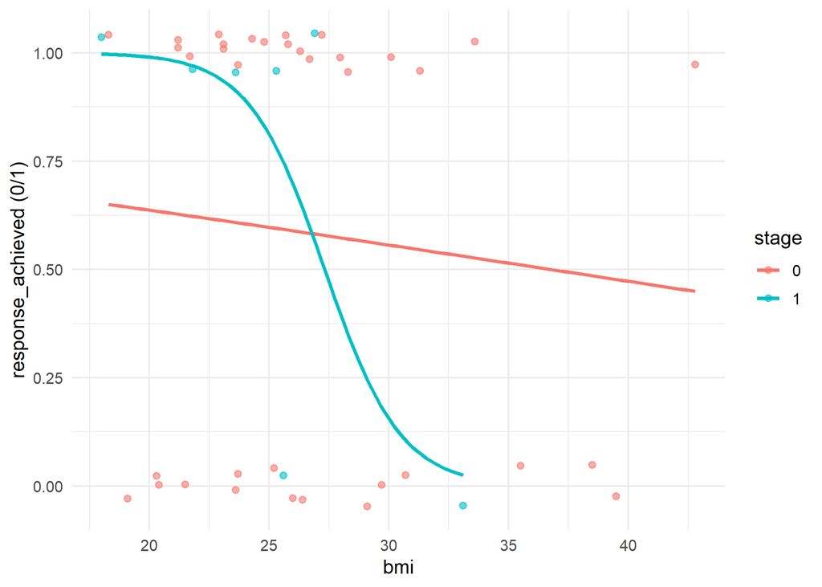

```r
p_bmi_adj <- try(plot_scatter_logit_adj(df, covar = resolve_or_identity(df, "bmi")), silent = TRUE)
if (!inherits(p_bmi_adj, "try-error") && !is.null(p_bmi_adj)) print(p_bmi_adj) else cat("No data for bmi.\n")
```

##### sex

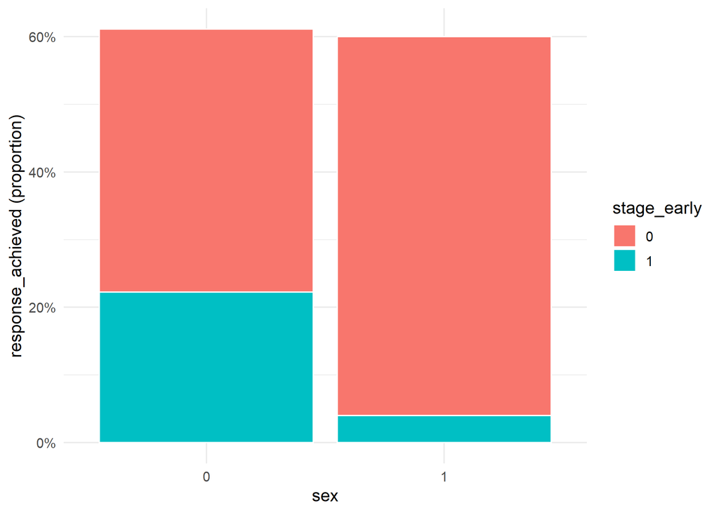

```r
p_sex_adj <- try(plot_stacked_by_stage(df, covar = resolve_or_identity(df, "sex")), silent = TRUE)
if (!inherits(p_sex_adj, "try-error") && !is.null(p_sex_adj)) print(p_sex_adj) else cat("No data for sex.\n")
```

##### ps_ecog

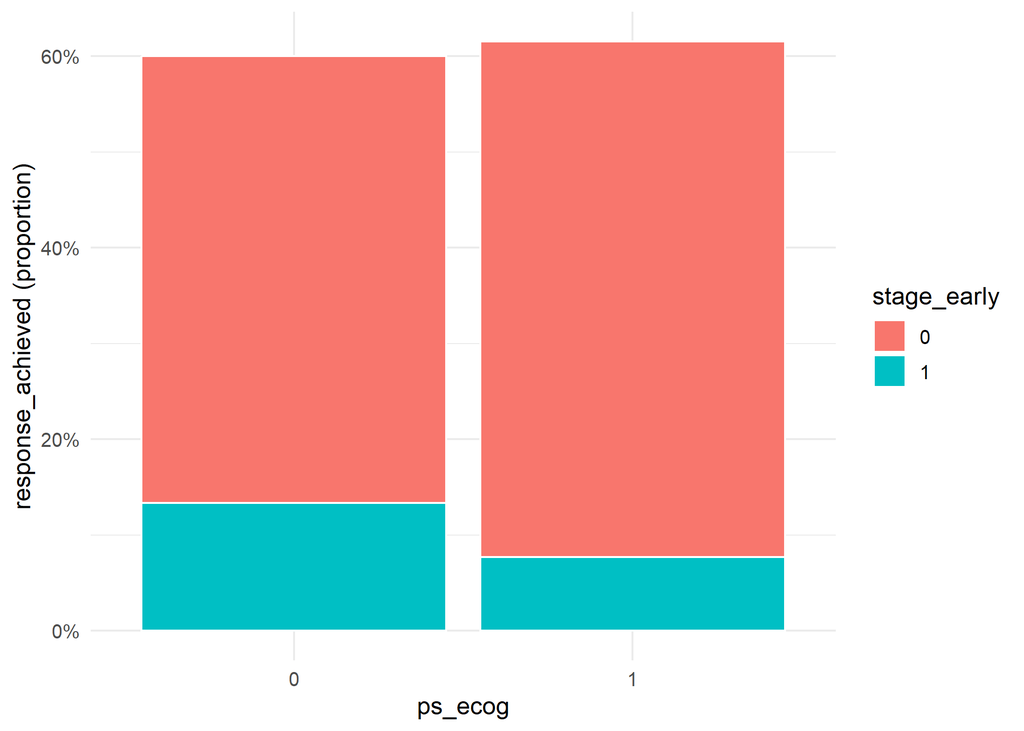

```r
p_ps_adj <- try(plot_stacked_by_stage(df, covar = resolve_or_identity(df, "ps_ecog")), silent = TRUE)
if (!inherits(p_ps_adj, "try-error") && !is.null(p_ps_adj)) print(p_ps_adj) else cat("No data for ps_ecog.\n")
```

##### first_syst_th

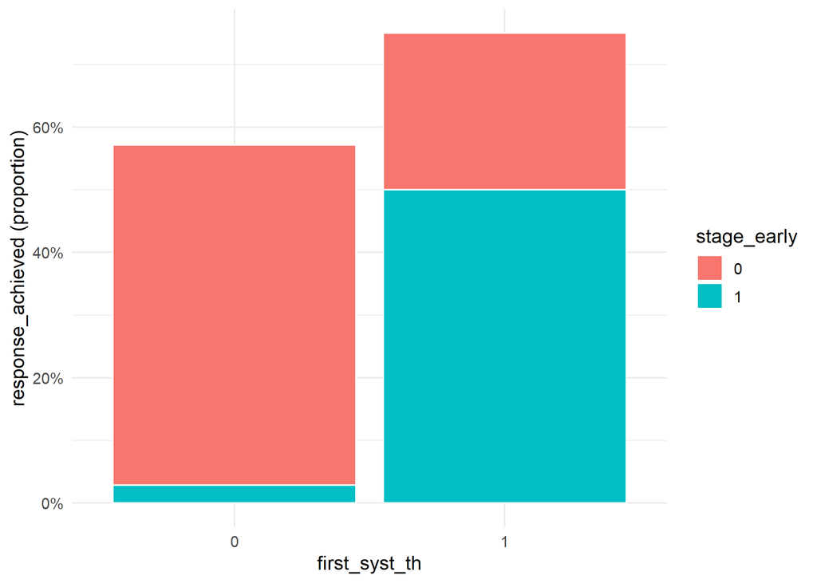

```r
p_first_adj <- try(plot_stacked_by_stage(df, covar = resolve_or_identity(df, "first_syst_th")), silent = TRUE)
if (!inherits(p_first_adj, "try-error") && !is.null(p_first_adj)) print(p_first_adj) else cat("No data for first_syst_th.\n")
```

##### monotherapy

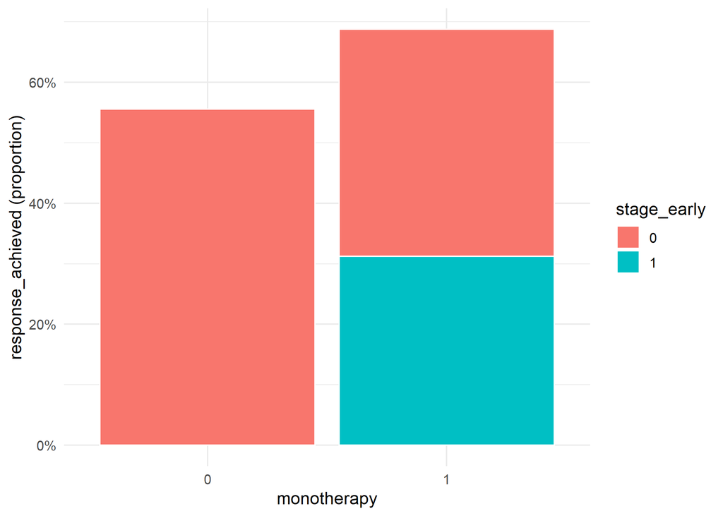

```r
p_mono_adj <- try(plot_stacked_by_stage(df, covar = resolve_or_identity(df, "monotherapy")), silent = TRUE)
if (!inherits(p_mono_adj, "try-error") && !is.null(p_mono_adj)) print(p_mono_adj) else cat("No data for monotherapy.\n")
```

##### ae_grade_3_4

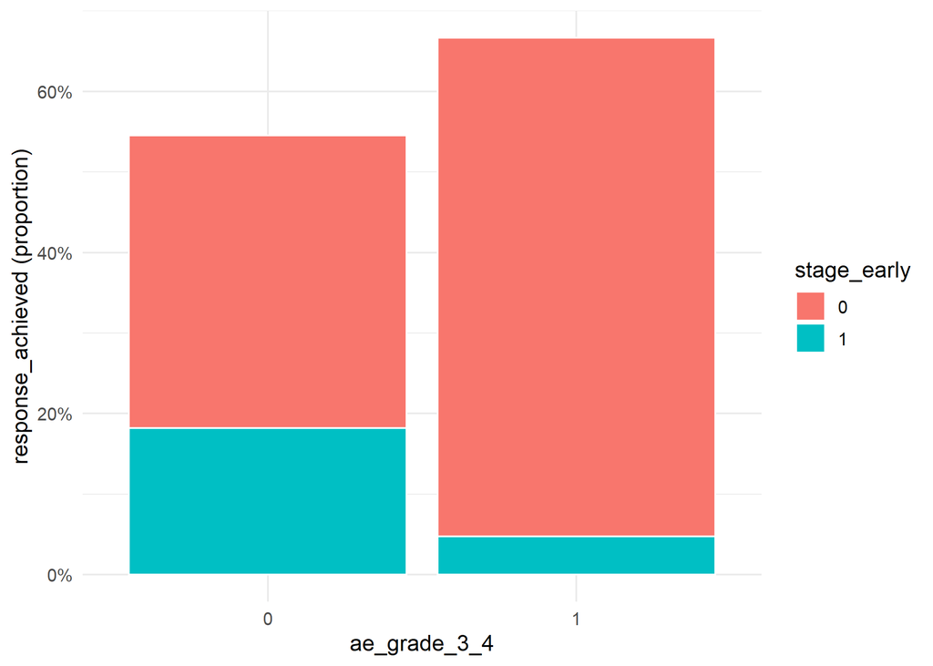

```r
p_ae_adj <- try(plot_stacked_by_stage(df, covar = resolve_or_identity(df, "ae_grade_3_4")), silent = TRUE)
if (!inherits(p_ae_adj, "try-error") && !is.null(p_ae_adj)) print(p_ae_adj) else cat("No data for ae_grade_3_4.\n")
```

### 5.2.2 Linear results

**The model equation (adjusted):**

$$\text{Time to response} = \beta_0 + \beta_1\,\mathrm{\text{Stage Early}}
+ \beta_2\,\text{Covariate} + \varepsilon, \quad \varepsilon \sim
\mathcal{N}(0,\sigma^2)$$

Where: beta_0 is the intercept (expected outcome when stage_early = 0 and the covariate is at its reference/0); beta_1 is the adjusted mean difference for stage_early (1 vs 0) holding the covariate fixed; beta_2 is the covariate effect (for factors: contrast versus the reference level; for numeric covariates: effect per one-unit increase); epsilon is a random error with mean 0 and variance sigma^2.

```r
# Adjusted linear models: response_time_to ~ stage_early + covariate (y > 0)
col_stage <- resolve_or_identity(df, "stage_early")
col_lin   <- resolve_or_identity(df, "response_time_to")
covars_lin <- c("age","sex","bmi","ps_ecog","first_syst_th","monotherapy","ae_grade_3_4")
covars_lin <- covars_lin[covars_lin %in% names(df)]

fit_adj_linear <- function(df, outcome_col, stage_col, covar_col) {
  d <- df |>
    dplyr::select(y = dplyr::all_of(outcome_col), stage = dplyr::all_of(stage_col), x = dplyr::all_of(covar_col)) |>
    dplyr::mutate(stage = as.factor(stage)) |>
    dplyr::filter(!is.na(y), !is.na(stage), is.finite(y), y > 0)
  if (nrow(d) == 0 || length(unique(d$stage)) < 2) return(NULL)
  # Treat numeric 0/1 predictors as factors for clear contrasts
  if (is.numeric(d$x)) {
    ux <- unique(d$x[!is.na(d$x)])
    if (length(ux) > 0 && all(ux %in% c(0,1))) d$x <- factor(as.integer(d$x))
  }
  d <- d |> dplyr::mutate(x = coerce_predictor(x))
  m <- tryCatch(stats::lm(y ~ stage + x, data = d), error = function(e) NULL)
  if (is.null(m)) return(NULL)
  tt <- broom::tidy(m, conf.int = TRUE)
  st <- tt |>
    dplyr::filter(stringr::str_detect(.data$term, "^stage")) |>
    dplyr::slice(1)
  if (is.factor(d$x)) {
    lab <- pick_contrast_level(d$x)
    cv <- if (is.null(lab)) tt |> dplyr::filter(stringr::str_starts(.data$term, "x")) |> dplyr::slice(1)
          else tt |> dplyr::filter(.data$term == paste0("x", lab)) |> dplyr::slice(1)
    if (nrow(cv) == 0) cv <- tt |> dplyr::filter(stringr::str_starts(.data$term, "x")) |> dplyr::slice(1)
  } else {
    cv <- tt |> dplyr::filter(.data$term == "x") |> dplyr::slice(1)
  }
  if (nrow(st) == 0 || nrow(cv) == 0) return(NULL)
  tibble::tibble(
    `estimate (stage_early)` = st$estimate,
    `p-value (stage_early)` = st$p.value,
    `95%CI (stage_early)` = sprintf("[%.2f, %.2f]", st$conf.low, st$conf.high),
    `estimate (covariate)` = cv$estimate,
    `p-value (covariate)` = cv$p.value,
    `95%CI (covariate)` = sprintf("[%.2f, %.2f]", cv$conf.low, cv$conf.high)
  )
}

adj_lin <- tidyr::expand_grid(Outcomes = col_lin, Covariate = covars_lin) |>
  dplyr::mutate(results = purrr::map(Covariate, ~ fit_adj_linear(df, outcome_col = col_lin, stage_col = col_stage, covar_col = .x))) |>
  dplyr::filter(!purrr::map_lgl(results, is.null)) |>
  tidyr::unnest(results)

if (nrow(adj_lin) > 0) {
  fmt_p <- function(p) ifelse(is.na(p), NA_character_, ifelse(p < 0.001, "<0.001", sprintf("%.3f", p)))
  out_tbl <- adj_lin |>
    dplyr::mutate(
      `estimate (stage_early)` = sprintf("%.3f", as.numeric(`estimate (stage_early)`)),
      `estimate (covariate)`   = sprintf("%.3f", as.numeric(`estimate (covariate)`)),
      `p-value (stage_early)`  = fmt_p(`p-value (stage_early)`),
      `p-value (covariate)`    = fmt_p(`p-value (covariate)`)
    )
  knitr::kable(out_tbl, align = "l",
               col.names = c("Outcomes","Covariate","estimate (stage_early)","p-value (stage_early)","95%CI (stage_early)","estimate (covariate)","p-value (covariate)","95%CI (covariate)")) %>%
    kableExtra::kable_styling(full_width = FALSE, bootstrap_options = c("striped","hover","condensed","responsive"))
} else {
  cat("No adjusted linear results available.\n")
}
```

| Outcomes | Covariate | estimate (stage_early) | p-value (stage_early) | 95%CI (stage_early) | estimate (covariate) | p-value (covariate) | 95%CI (covariate) |
| --- | --- | --- | --- | --- | --- | --- | --- |
| response_time_to | age | -1.265 | 0.393 | [-4.26, 1.73] | -0.012 | 0.792 | [-0.10, 0.08] |
| response_time_to | sex | -1.986 | 0.207 | [-5.14, 1.17] | -1.498 | 0.224 | [-3.98, 0.98] |
| response_time_to | bmi | -0.263 | 0.843 | [-2.98, 2.45] | 0.286 | 0.010 | [0.08, 0.50] |
| response_time_to | ps_ecog | -1.209 | 0.416 | [-4.22, 1.80] | 0.334 | 0.789 | [-2.21, 2.88] |
| response_time_to | first_syst_th | 0.192 | 0.920 | [-3.73, 4.11] | -2.013 | 0.268 | [-5.67, 1.64] |
| response_time_to | monotherapy | -0.367 | 0.837 | [-3.99, 3.26] | -1.186 | 0.399 | [-4.03, 1.66] |
| response_time_to | ae_grade_3_4 | -1.791 | 0.242 | [-4.87, 1.29] | -1.339 | 0.254 | [-3.70, 1.02] |

```r
# Stage-specific covariate effects (linear): factor x via emmeans(~ x | stage) contrasts; numeric x via emtrends(~ stage, var = "x")
if (!requireNamespace("emmeans", quietly = TRUE)) {
  cat("emmeans package not available; stage-wise linear effects skipped.\n")
} else {
  fmt_p_str <- function(p) ifelse(is.na(p), NA_character_, ifelse(p < 0.001, "<0.001", sprintf("%.3f", p)))
  fmt_ci_str <- function(l, u) ifelse(is.na(l) | is.na(u), NA_character_, sprintf("[%.2f, %.2f]", l, u))

  compute_stagewise_lin <- function(df, outcome_col, stage_col, covar_col) {
    d <- df |>
      dplyr::select(y = dplyr::all_of(outcome_col), stage = dplyr::all_of(stage_col), x = dplyr::all_of(covar_col)) |>
      dplyr::mutate(stage = as.factor(stage)) |>
      dplyr::filter(!is.na(y), !is.na(stage), is.finite(y), y > 0)
    if (nrow(d) == 0 || length(unique(d$stage)) < 2) return(NULL)
    if (is.numeric(d$x)) {
      ux <- unique(d$x[!is.na(d$x)]); if (length(ux) > 0 && all(ux %in% c(0,1))) d$x <- factor(as.integer(d$x))
    }
    d <- d |> dplyr::mutate(x = coerce_predictor(x))
    m_int <- tryCatch(stats::lm(y ~ stage * x, data = d), error = function(e) NULL)
    if (is.null(m_int)) return(NULL)
    out <- tibble::tibble(
      `estimate (stage_early = 0)` = NA_real_,
      `p-value (stage_early = 0)` = NA_character_,
      `95%CI (stage_early = 0)` = NA_character_,
      `estimate (stage_early = 1)` = NA_real_,
      `p-value (stage_early = 1)` = NA_character_,
      `95%CI (stage_early = 1)` = NA_character_
    )

    if (is.factor(d$x)) {
      em <- try(emmeans::emmeans(m_int, specs = ~ x | stage), silent = TRUE)
      if (!inherits(em, "try-error")) {
        cn <- try(emmeans::contrast(em, method = "trt.vs.ctrl", ref = 1), silent = TRUE)
        sm <- try(as.data.frame(summary(cn, infer = TRUE)), silent = TRUE)
        if (!inherits(sm, "try-error") && nrow(sm) > 0) {
          st_vals <- if ("stage" %in% names(sm)) unique(as.character(sm$stage)) else levels(d$stage)
          s0 <- if (length(st_vals) >= 1) (if ("0" %in% st_vals) "0" else st_vals[1]) else NA_character_
          s1 <- if (length(st_vals) >= 2) (if ("1" %in% st_vals) "1" else st_vals[2]) else NA_character_
          if (!is.na(s0)) {
            r0 <- sm[as.character(sm$stage) == s0, , drop = FALSE]
            if (nrow(r0) >= 1) {
              out$`estimate (stage_early = 0)` <- as.numeric(r0$estimate[1])
              out$`p-value (stage_early = 0)` <- fmt_p_str(as.numeric(r0$p.value[1]))
              out$`95%CI (stage_early = 0)` <- fmt_ci_str(as.numeric(r0$lower.CL[1]), as.numeric(r0$upper.CL[1]))
            }
          }
          if (!is.na(s1)) {
            r1 <- sm[as.character(sm$stage) == s1, , drop = FALSE]
            if (nrow(r1) >= 1) {
              out$`estimate (stage_early = 1)` <- as.numeric(r1$estimate[1])
              out$`p-value (stage_early = 1)` <- fmt_p_str(as.numeric(r1$p.value[1]))
              out$`95%CI (stage_early = 1)` <- fmt_ci_str(as.numeric(r1$lower.CL[1]), as.numeric(r1$upper.CL[1]))
            }
          }
        }
      }
    } else {
      tr <- try(emmeans::emtrends(m_int, specs = ~ stage, var = "x"), silent = TRUE)
      if (!inherits(tr, "try-error")) {
        smt <- try(as.data.frame(summary(tr, infer = TRUE)), silent = TRUE)
        if (!inherits(smt, "try-error") && nrow(smt) > 0) {
          trend_name <- if ("emtrends" %in% names(smt)) "emtrends" else if ("x.trend" %in% names(smt)) "x.trend" else if ("trend" %in% names(smt)) "trend" else NA_character_
          st_vals <- if ("stage" %in% names(smt)) unique(as.character(smt$stage)) else levels(d$stage)
          s0 <- if (length(st_vals) >= 1) (if ("0" %in% st_vals) "0" else st_vals[1]) else NA_character_
          s1 <- if (length(st_vals) >= 2) (if ("1" %in% st_vals) "1" else st_vals[2]) else NA_character_
          if (!is.na(s0)) {
            r0 <- smt[as.character(smt$stage) == s0, , drop = FALSE]
            if (nrow(r0) >= 1) {
              out$`estimate (stage_early = 0)` <- as.numeric(r0[[trend_name]][1])
              out$`p-value (stage_early = 0)` <- fmt_p_str(as.numeric(r0$p.value[1]))
              out$`95%CI (stage_early = 0)` <- fmt_ci_str(as.numeric(r0$lower.CL[1]), as.numeric(r0$upper.CL[1]))
            }
          }
          if (!is.na(s1)) {
            r1 <- smt[as.character(smt$stage) == s1, , drop = FALSE]
            if (nrow(r1) >= 1) {
              out$`estimate (stage_early = 1)` <- as.numeric(r1[[trend_name]][1])
              out$`p-value (stage_early = 1)` <- fmt_p_str(as.numeric(r1$p.value[1]))
              out$`95%CI (stage_early = 1)` <- fmt_ci_str(as.numeric(r1$lower.CL[1]), as.numeric(r1$upper.CL[1]))
            }
          }
        }
      }
    }
    out
  }

  stagewise_lin <- tidyr::expand_grid(outcomes = col_lin, covariates = covars_lin) |>
    dplyr::mutate(results = purrr::map(covariates, ~ compute_stagewise_lin(df, outcome_col = col_lin, stage_col = col_stage, covar_col = .x))) |>
    dplyr::filter(!purrr::map_lgl(results, is.null)) |>
    tidyr::unnest(results)

  if (nrow(stagewise_lin) > 0) {
    stagewise_lin_disp <- stagewise_lin |>
      dplyr::mutate(
        `estimate (stage_early = 0)` = ifelse(is.na(`estimate (stage_early = 0)`), NA_character_, sprintf("%.3f", as.numeric(`estimate (stage_early = 0)`))),
        `estimate (stage_early = 1)` = ifelse(is.na(`estimate (stage_early = 1)`), NA_character_, sprintf("%.3f", as.numeric(`estimate (stage_early = 1)`)))
      )
    knitr::kable(stagewise_lin_disp, align = "l",
                 col.names = c(
                   "outcomes","covariates",
                   "estimate (stage_early = 0)","p-value (stage_early = 0)","95%CI (stage_early = 0)",
                   "estimate (stage_early = 1)","p-value (stage_early = 1)","95%CI (stage_early = 1)"
                 )) %>%
      kableExtra::kable_styling(full_width = FALSE, bootstrap_options = c("striped","hover","condensed","responsive"))
  } else {
    cat("No stage-wise linear effects available.\n")
  }
}
```

| outcomes | covariates | estimate (stage_early = 0) | p-value (stage_early = 0) | 95%CI (stage_early = 0) | estimate (stage_early = 1) | p-value (stage_early = 1) | 95%CI (stage_early = 1) |
| --- | --- | --- | --- | --- | --- | --- | --- |
| response_time_to | age | -0.020 | 0.704 | [-0.13, 0.09] | 0.015 | 0.877 | [-0.18, 0.21] |
| response_time_to | sex | -1.991 | 0.138 | [-4.67, 0.69] | 1.500 | 0.644 | [-5.11, 8.11] |
| response_time_to | bmi | 0.283 | 0.015 | [0.06, 0.51] | 0.327 | 0.402 | [-0.46, 1.12] |
| response_time_to | ps_ecog | 0.759 | 0.577 | [-2.01, 3.53] | -2.250 | 0.504 | [-9.09, 4.59] |
| response_time_to | first_syst_th | -2.238 | 0.313 | [-6.72, 2.25] | -1.500 | 0.652 | [-8.27, 5.27] |
| response_time_to | monotherapy | -1.186 | 0.399 | [-4.03, 1.66] |  |  |  |
| response_time_to | ae_grade_3_4 | -1.206 | 0.344 | [-3.79, 1.38] | -2.250 | 0.498 | [-9.01, 4.51] |

#### Plots - linear

```r
# Helpers for appended linear plots (match Logistic plots palette/theme)
# Columns resolved via resolve_or_identity to respect alias_map
col_stage <- resolve_or_identity(df, 'stage_early')
col_y     <- resolve_or_identity(df, 'response_time_to')

lin_end_scatter_by_stage <- function(df, covar) {
  # Resolve columns locally
  y_col     <- resolve_or_identity(df, 'response_time_to')
  stage_col <- resolve_or_identity(df, 'stage_early')
  x_col     <- resolve_or_identity(df, covar)
  if (!all(c(y_col, stage_col, x_col) %in% names(df))) return(NULL)
  d <- df |>
    dplyr::select(y = dplyr::all_of(y_col), stage = dplyr::all_of(stage_col), x = dplyr::all_of(x_col)) |>
    dplyr::filter(!is.na(y), !is.na(stage), !is.na(x), is.finite(y), y > 0) |>
    dplyr::mutate(stage = as.factor(stage))
  if (nrow(d) < 2) return(NULL)
  pal <- scales::hue_pal()(length(levels(d$stage))); names(pal) <- levels(d$stage)
  ggplot2::ggplot(d, ggplot2::aes(x = x, y = y, color = stage)) +
    ggplot2::geom_point(alpha = 0.6, size = 1.7) +
    ggplot2::geom_smooth(method = 'lm', se = FALSE) +
    ggplot2::scale_color_manual(values = pal, name = 'stage_early') +
    ggplot2::labs(x = x_col, y = y_col, title = sprintf('%s vs %s by stage', y_col, x_col)) +
    ggplot2::theme_minimal(base_size = 12)
}

lin_end_jitter_boot_by_stage <- function(df, covar) {
  if (!all(c('response_time_to','stage_early', covar) %in% names(df))) return(NULL)

  d <- df |>
    dplyr::transmute(
      y = .data[["response_time_to"]],
      stage = as.factor(.data[["stage_early"]]),
      x = forcats::fct_explicit_na(as.factor(.data[[covar]]), na_level = 'Missing')
    ) |>
    na.omit()

  pal <- scales::hue_pal()(length(levels(d$stage)))
  names(pal) <- levels(d$stage)

  ci_df <- d |>
    dplyr::group_by(x, stage) |>
    dplyr::summarise({
      v <- y[is.finite(y)]
      if (length(v) == 0) {
        tibble::tibble(med = NA_real_, l = NA_real_, u = NA_real_)
      } else if (length(v) == 1) {
        tibble::tibble(med = stats::median(v), l = NA_real_, u = NA_real_)
      } else {
        meds <- replicate(5000L, stats::median(sample(v, replace = TRUE)))
        tibble::tibble(
          med = stats::median(v),
          l = stats::quantile(meds, 0.025, names = FALSE),
          u = stats::quantile(meds, 0.975, names = FALSE)
        )
      }
    }, .groups = "drop")

  ggplot2::ggplot(d, ggplot2::aes(x = x, y = y, color = stage)) +
    ggplot2::geom_point(
      alpha = 0.6, size = 1.7, stroke = 0,
      position = ggplot2::position_jitterdodge(jitter.width = 0.15, dodge.width = 0.6)
    ) +
    ggplot2::geom_errorbar(
      data = ci_df,
      ggplot2::aes(x = x, ymin = l, ymax = u, color = stage),
      width = 0.15,
      position = ggplot2::position_dodge(width = 0.6),
      inherit.aes = FALSE, na.rm = TRUE
    ) +
    ggplot2::geom_point(
      data = ci_df,
      ggplot2::aes(x = x, y = med, color = stage, group = stage),
      color = 'black', size = 2.5,
      position = ggplot2::position_dodge(width = 0.6),
      inherit.aes = TRUE, na.rm = TRUE
    ) +
    ggplot2::scale_color_manual(values = pal, name = "Stage") +
    ggplot2::labs(
      x = covar, y = "response_time_to",
      title = sprintf("%s by %s (median with 95%% CI)", "response_time_to", covar)
    ) +
    ggplot2::theme_minimal(base_size = 12)
}
```

##### age

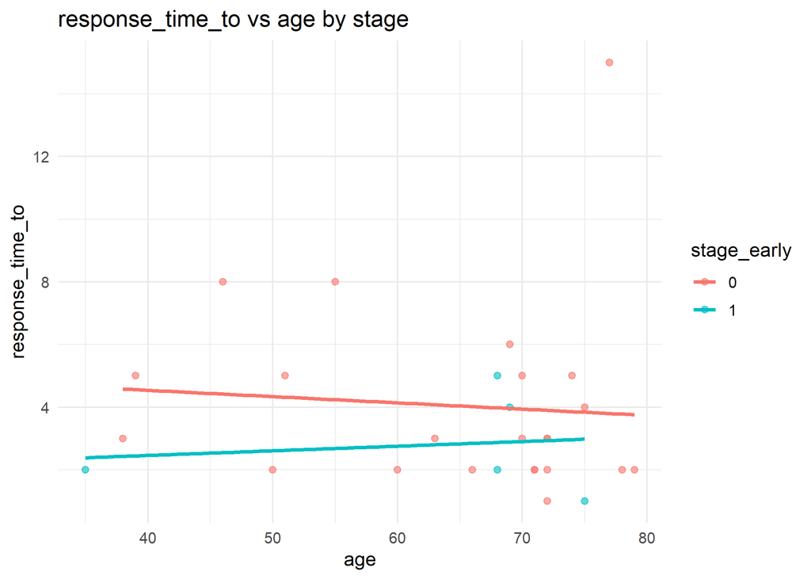

```r
p_age_lin_end <- try(lin_end_scatter_by_stage(df, covar = resolve_or_identity(df, 'age')), silent = TRUE)
if (!inherits(p_age_lin_end, 'try-error') && !is.null(p_age_lin_end)) print(p_age_lin_end) else cat('No data for age.\n')
```

##### bmi

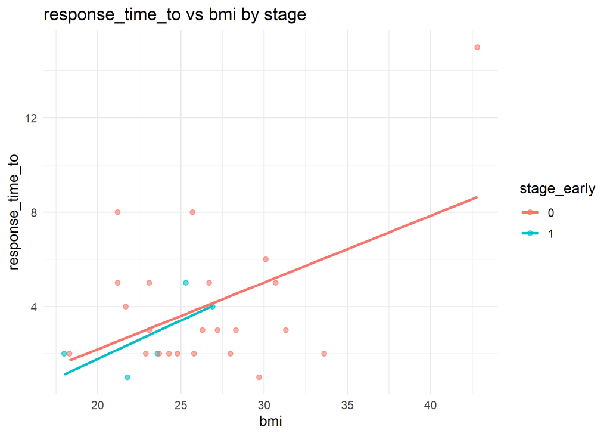

```r
p_bmi_lin_end <- try(lin_end_scatter_by_stage(df, covar = resolve_or_identity(df, 'bmi')), silent = TRUE)
if (!inherits(p_bmi_lin_end, 'try-error') && !is.null(p_bmi_lin_end)) print(p_bmi_lin_end) else cat('No data for bmi.\n')
```

##### sex

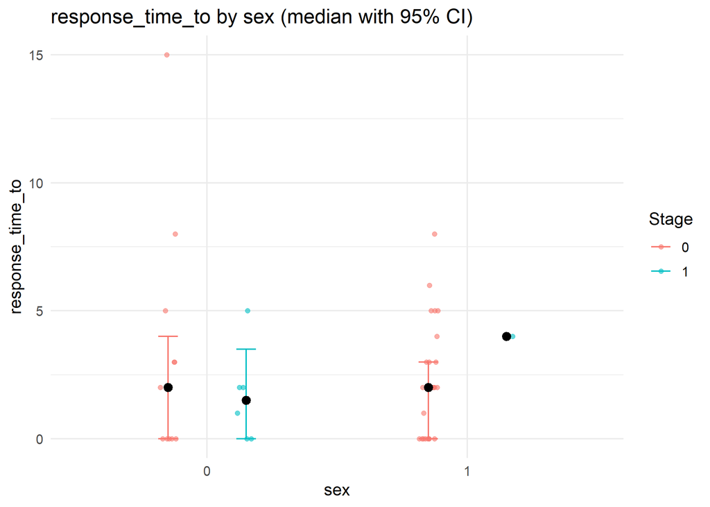

```r
p_sex_lin_end <- try(lin_end_jitter_boot_by_stage(df, covar = resolve_or_identity(df, 'sex')), silent = TRUE)
if (!inherits(p_sex_lin_end, 'try-error') && !is.null(p_sex_lin_end)) print(p_sex_lin_end) else cat('No data for sex.\n')
```

##### ps_ecog

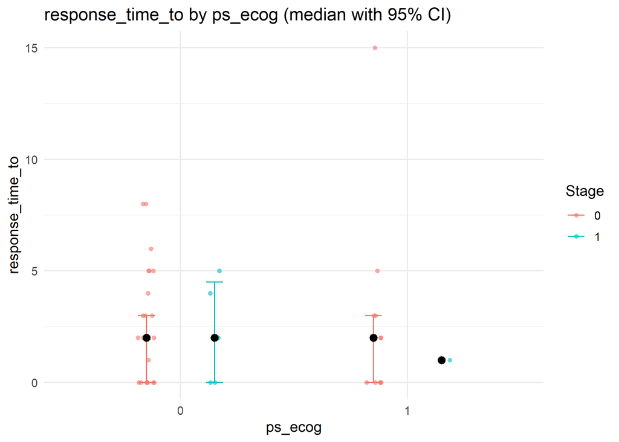

```r
p_ps_lin_end <- try(lin_end_jitter_boot_by_stage(df, covar = resolve_or_identity(df, 'ps_ecog')), silent = TRUE)
if (!inherits(p_ps_lin_end, 'try-error') && !is.null(p_ps_lin_end)) print(p_ps_lin_end) else cat('No data for ps_ecog.\n')
```

##### first_syst_th

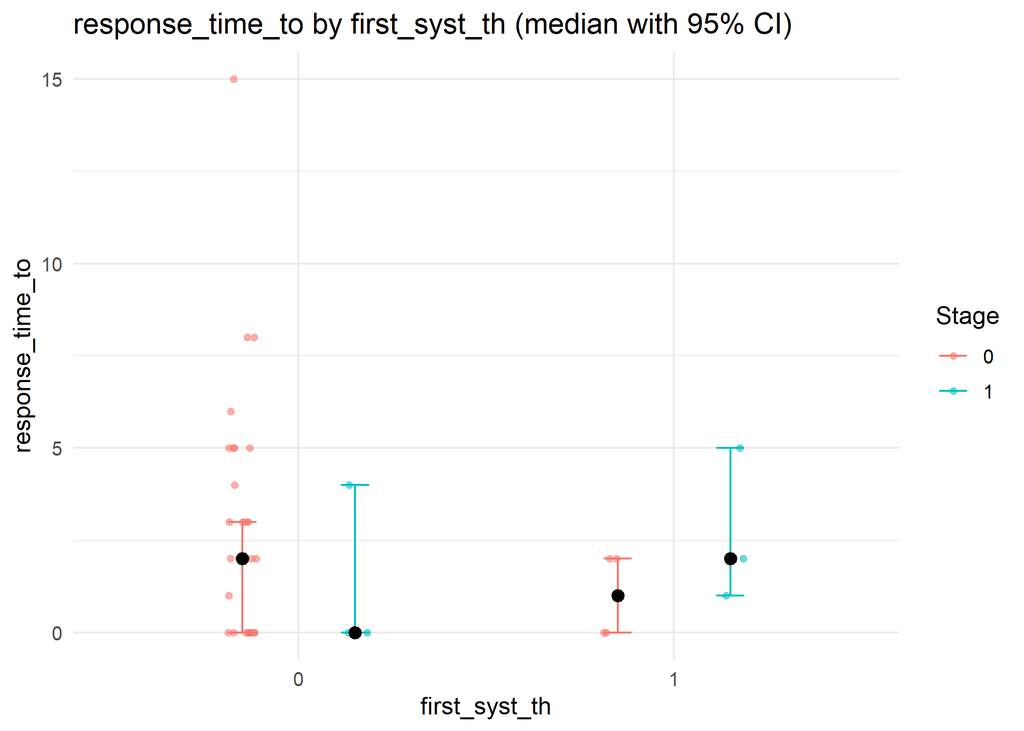

```r
p_first_lin_end <- try(lin_end_jitter_boot_by_stage(df, covar = resolve_or_identity(df, 'first_syst_th')), silent = TRUE)
if (!inherits(p_first_lin_end, 'try-error') && !is.null(p_first_lin_end)) print(p_first_lin_end) else cat('No data for first_syst_th.\n')
```

##### monotherapy

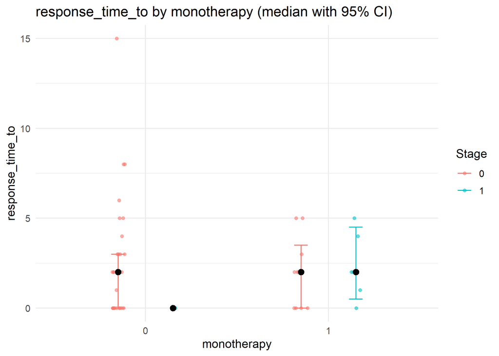

```r
p_mono_lin_end <- try(lin_end_jitter_boot_by_stage(df, covar = resolve_or_identity(df, 'monotherapy')), silent = TRUE)
if (!inherits(p_mono_lin_end, 'try-error') && !is.null(p_mono_lin_end)) print(p_mono_lin_end) else cat('No data for monotherapy.\n')
```

##### ae_grade_3_4

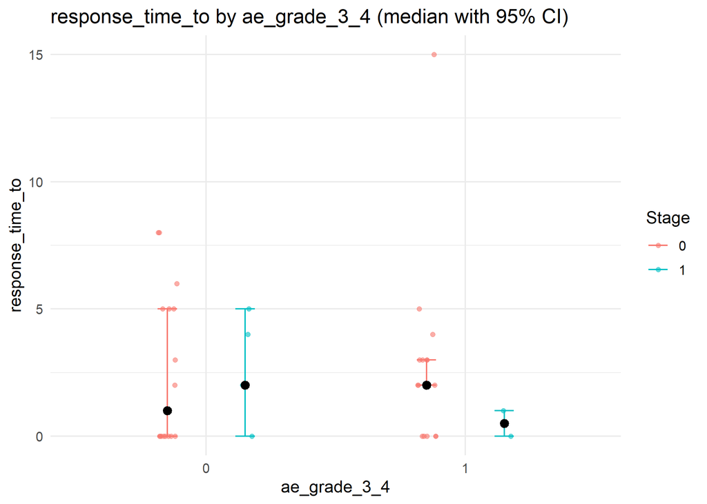

```r
p_ae_lin_end <- try(lin_end_jitter_boot_by_stage(df, covar = resolve_or_identity(df, 'ae_grade_3_4')), silent = TRUE)
if (!inherits(p_ae_lin_end, 'try-error') && !is.null(p_ae_lin_end)) print(p_ae_lin_end) else cat('No data for ae_grade_3_4.\n')
```

### 5.2.3 Survival results

**The model equation (adjusted):**

$$h(t \mid \text{Stage Early}, \text{Covariate})
= h_0(t)\,\exp\!\big(\beta_1\,\text{Stage Early} +
\beta_2\,\text{Covariate}\big)$$

Where: h(t) is the hazard at time t; h0(t) is the baseline hazard; beta_1 is the adjusted log‑hazard ratio for stage_early (1 vs 0) holding the covariate fixed; beta_2 is the covariate effect (for factors: contrast vs the reference level; for numeric covariates: effect per one‑unit increase). Effects are commonly reported as HR = exp(beta).

```r
# Adjusted Cox PH for three endpoints with single-covariate adjustments
# Columns resolved directly from df; no prior filtering
col_stage <- 'stage_early'
endpoints <- list(
  list(label = 'time_to_next_treatment', time = 'ttnt',                 event = 'ttnt_achieved'),
  list(label = 'treatment_duration',      time = 'treatment_duration',  event = 'discontinuation_reason'),
  list(label = 'response_duration',       time = 'response_duration',   event = 'progression')
)

covars_surv <- c('age','sex','bmi','ps_ecog','first_syst_th','monotherapy','ae_grade_3_4')
covars_surv <- covars_surv[covars_surv %in% names(df)]

fit_adj_cox_app <- function(df, spec, stage_col, covar_col) {
  if (!all(c(spec$time, spec$event, stage_col, covar_col) %in% names(df))) return(NULL)
  d <- df |>
    dplyr::transmute(
      time  = suppressWarnings(readr::parse_number(as.character(.data[[spec$time]]))),
      event = .data[[spec$event]],
      stage = as.factor(.data[[stage_col]]),
      x     = .data[[covar_col]]
    ) |>
    dplyr::mutate(
      event = {
        v <- event
        if (is.factor(v)) v <- as.character(v)
        v <- suppressWarnings(as.numeric(v))
        ifelse(is.na(v), NA_real_, ifelse(v == 0, 0, 1))
      },
      x = if (is.numeric(x) && all(na.omit(unique(x)) %in% c(0,1))) factor(as.integer(x)) else x,
      x = if (is.character(x)) factor(x) else x
    ) |>
    dplyr::filter(!is.na(time), !is.na(event), !is.na(stage), !is.na(x))
  if (nrow(d) < 3 || length(unique(d$stage)) < 2) return(NULL)
  m <- tryCatch(survival::coxph(survival::Surv(time, event) ~ stage + x, data = d, x = TRUE), error = function(e) NULL)
  if (is.null(m)) return(NULL)
  tt <- broom::tidy(m, conf.int = TRUE, exponentiate = TRUE)
  st <- tt |>
    dplyr::filter(stringr::str_detect(.data$term, '^stage')) |>
    dplyr::slice(1)
  cv <- if (is.factor(d$x)) {
    lab <- levels(d$x)[2]
    row <- tt |> dplyr::filter(stringr::str_starts(.data$term, 'x')) |> dplyr::slice(1)
    row
  } else {
    tt |> dplyr::filter(.data$term == 'x') |> dplyr::slice(1)
  }
  if (nrow(st) == 0 || nrow(cv) == 0) return(NULL)
  tibble::tibble(
    `HR (stage_early)` = as.numeric(st$estimate),
    `p-value (stage_early)` = ifelse(is.na(st$p.value), NA_character_, ifelse(st$p.value < 0.001, '<0.001', sprintf('%.3f', st$p.value))),
    `95%CI (stage_early)` = sprintf('[%.2f, %.2f]', as.numeric(st$conf.low), as.numeric(st$conf.high)),
    `HR (covariate)` = as.numeric(cv$estimate),
    `p-value (covariate)` = ifelse(is.na(cv$p.value), NA_character_, ifelse(cv$p.value < 0.001, '<0.001', sprintf('%.3f', cv$p.value))),
    `95%CI (covariate)` = sprintf('[%.2f, %.2f]', as.numeric(cv$conf.low), as.numeric(cv$conf.high))
  )
}

adj_surv_app <- tidyr::expand_grid(spec_id = seq_along(endpoints), Covariate = covars_surv) |>
  dplyr::mutate(results = purrr::map2(spec_id, Covariate, ~ fit_adj_cox_app(df, endpoints[[.x]], stage_col = col_stage, covar_col = .y))) |>
  dplyr::filter(!purrr::map_lgl(results, is.null)) |>
  tidyr::unnest(results) |>
  dplyr::mutate(Outcomes = vapply(spec_id, function(i) endpoints[[i]]$label, character(1))) |>
  dplyr::select(Outcomes, Covariate, dplyr::everything(), -spec_id)

if (nrow(adj_surv_app) > 0) {
  knitr::kable(adj_surv_app, align = 'l',
               col.names = c('Outcomes','Covariate','HR (stage_early)','p-value (stage_early)','95%CI (stage_early)',
                             'HR (covariate)','p-value (covariate)','95%CI (covariate)')) |>
    kableExtra::kable_styling(full_width = FALSE, bootstrap_options = c('striped','hover','condensed','responsive'))
} else {
  cat('No adjusted survival results available.\n')
}
```

| Outcomes | Covariate | HR (stage_early) | p-value (stage_early) | 95%CI (stage_early) | HR (covariate) | p-value (covariate) | 95%CI (covariate) |
| --- | --- | --- | --- | --- | --- | --- | --- |
| time_to_next_treatment | age | 0.2823083 | 0.027 | [0.09, 0.87] | 1.0150674 | 0.299 | [0.99, 1.04] |
| time_to_next_treatment | sex | 0.2509473 | 0.027 | [0.07, 0.85] | 0.9476615 | 0.890 | [0.44, 2.04] |
| time_to_next_treatment | bmi | 0.2554575 | 0.019 | [0.08, 0.80] | 0.9954188 | 0.888 | [0.93, 1.06] |
| time_to_next_treatment | ps_ecog | 0.2597770 | 0.019 | [0.08, 0.80] | 0.9999700 | 1.000 | [0.48, 2.10] |
| time_to_next_treatment | first_syst_th | 0.3061480 | 0.080 | [0.08, 1.15] | 0.7714682 | 0.664 | [0.24, 2.48] |
| time_to_next_treatment | monotherapy | 0.2853198 | 0.036 | [0.09, 0.92] | 0.7810483 | 0.545 | [0.35, 1.74] |
| time_to_next_treatment | ae_grade_3_4 | 0.2025771 | 0.010 | [0.06, 0.68] | 0.6513139 | 0.256 | [0.31, 1.37] |
| treatment_duration | age | 1.1357847 | 0.770 | [0.48, 2.66] | 1.0397371 | 0.028 | [1.00, 1.08] |
| treatment_duration | sex | 0.9397420 | 0.899 | [0.36, 2.45] | 0.8100360 | 0.601 | [0.37, 1.78] |
| treatment_duration | bmi | 1.1630804 | 0.734 | [0.49, 2.78] | 1.0376018 | 0.280 | [0.97, 1.11] |
| treatment_duration | ps_ecog | 1.1219982 | 0.793 | [0.47, 2.66] | 1.3711920 | 0.406 | [0.65, 2.89] |
| treatment_duration | first_syst_th | 0.8316149 | 0.741 | [0.28, 2.48] | 1.4649583 | 0.471 | [0.52, 4.14] |
| treatment_duration | monotherapy | 0.9618253 | 0.935 | [0.38, 2.46] | 1.2073593 | 0.633 | [0.56, 2.62] |
| treatment_duration | ae_grade_3_4 | 1.2240550 | 0.660 | [0.50, 3.01] | 1.4586152 | 0.331 | [0.68, 3.12] |
| response_duration | age | 0.4769059 | 0.244 | [0.14, 1.66] | 1.0378771 | 0.084 | [1.00, 1.08] |
| response_duration | sex | 0.8040653 | 0.769 | [0.19, 3.44] | 2.3905597 | 0.149 | [0.73, 7.81] |
| response_duration | bmi | 0.5250352 | 0.321 | [0.15, 1.87] | 1.0508205 | 0.217 | [0.97, 1.14] |
| response_duration | ps_ecog | 0.4729569 | 0.241 | [0.14, 1.65] | 1.1975919 | 0.691 | [0.49, 2.91] |
| response_duration | first_syst_th | 0.7826436 | 0.740 | [0.18, 3.33] | 0.3681901 | 0.254 | [0.07, 2.05] |
| response_duration | monotherapy | 0.7147798 | 0.625 | [0.19, 2.75] | 0.3867022 | 0.088 | [0.13, 1.15] |
| response_duration | ae_grade_3_4 | 0.4456282 | 0.215 | [0.12, 1.60] | 0.9116132 | 0.844 | [0.36, 2.29] |

```r
# Stage-wise Cox PH: within each stage, Surv ~ covariate for each endpoint
col_stage <- 'stage_early'

compute_stagewise_cox_app <- function(df, spec, stage_col, covar_col) {
  if (!all(c(spec$time, spec$event, stage_col, covar_col) %in% names(df))) return(NULL)
  d <- df |>
    dplyr::transmute(
      time  = suppressWarnings(readr::parse_number(as.character(.data[[spec$time]]))),
      event = .data[[spec$event]],
      stage = as.factor(.data[[stage_col]]),
      x     = .data[[covar_col]]
    ) |>
    dplyr::mutate(
      event = {
        v <- event
        if (is.factor(v)) v <- as.character(v)
        v <- suppressWarnings(as.numeric(v))
        ifelse(is.na(v), NA_real_, ifelse(v == 0, 0, 1))
      },
      x = if (is.numeric(x) && all(na.omit(unique(x)) %in% c(0,1))) factor(as.integer(x)) else x,
      x = if (is.character(x)) factor(x) else x
    ) |>
    dplyr::filter(!is.na(time), !is.na(event), !is.na(stage), !is.na(x))
  if (nrow(d) < 3 || length(unique(d$stage)) < 1) return(NULL)
  out <- tibble::tibble(
    `HR (stage_early = 0)` = NA_real_, `p-value (stage_early = 0)` = NA_character_, `95%CI (stage_early = 0)` = NA_character_,
    `HR (stage_early = 1)` = NA_real_, `p-value (stage_early = 1)` = NA_character_, `95%CI (stage_early = 1)` = NA_character_
  )
  levels_stage <- levels(d$stage)
  s0 <- if ('0' %in% levels_stage) '0' else levels_stage[1]
  s1 <- if (length(levels_stage) >= 2) (if ('1' %in% levels_stage) '1' else levels_stage[2]) else NA_character_
  if (!is.na(s0)) {
    d0 <- d[as.character(d$stage) == s0, , drop = FALSE]
    if (nrow(d0) >= 3) {
      m0 <- tryCatch(survival::coxph(survival::Surv(time, event) ~ x, data = d0), error = function(e) NULL)
      if (!is.null(m0)) {
        t0 <- broom::tidy(m0, conf.int = TRUE, exponentiate = TRUE)
        r0 <- if (is.factor(d0$x)) t0 |> dplyr::filter(stringr::str_starts(.data$term, 'x')) |> dplyr::slice(1) else t0 |> dplyr::filter(.data$term == 'x') |> dplyr::slice(1)
        if (nrow(r0) == 1) {
          out$`HR (stage_early = 0)` <- as.numeric(r0$estimate)
          out$`p-value (stage_early = 0)` <- ifelse(is.na(r0$p.value), NA_character_, ifelse(r0$p.value < 0.001, '<0.001', sprintf('%.3f', r0$p.value)))
          out$`95%CI (stage_early = 0)` <- sprintf('[%.2f, %.2f]', as.numeric(r0$conf.low), as.numeric(r0$conf.high))
        }
      }
    }
  }
  if (!is.na(s1)) {
    d1 <- d[as.character(d$stage) == s1, , drop = FALSE]
    if (nrow(d1) >= 3) {
      m1 <- tryCatch(survival::coxph(survival::Surv(time, event) ~ x, data = d1), error = function(e) NULL)
      if (!is.null(m1)) {
        t1 <- broom::tidy(m1, conf.int = TRUE, exponentiate = TRUE)
        r1 <- if (is.factor(d1$x)) t1 |> dplyr::filter(stringr::str_starts(.data$term, 'x')) |> dplyr::slice(1) else t1 |> dplyr::filter(.data$term == 'x') |> dplyr::slice(1)
        if (nrow(r1) == 1) {
          out$`HR (stage_early = 1)` <- as.numeric(r1$estimate)
          out$`p-value (stage_early = 1)` <- ifelse(is.na(r1$p.value), NA_character_, ifelse(r1$p.value < 0.001, '<0.001', sprintf('%.3f', r1$p.value)))
          out$`95%CI (stage_early = 1)` <- sprintf('[%.2f, %.2f]', as.numeric(r1$conf.low), as.numeric(r1$conf.high))
        }
      }
    }
  }
  out
}

stagewise_surv_app <- tidyr::expand_grid(spec_id = seq_along(endpoints), Covariate = covars_surv) |>
  dplyr::mutate(results = purrr::map2(spec_id, Covariate, ~ compute_stagewise_cox_app(df, endpoints[[.x]], stage_col = col_stage, covar_col = .y))) |>
  dplyr::filter(!purrr::map_lgl(results, is.null)) |>
  tidyr::unnest(results) |>
  dplyr::mutate(outcomes = vapply(spec_id, function(i) endpoints[[i]]$label, character(1))) |>
  dplyr::select(outcomes, covariates = Covariate, dplyr::everything(), -spec_id)

if (nrow(stagewise_surv_app) > 0) {
  knitr::kable(stagewise_surv_app, align = 'l',
               col.names = c('outcomes','covariates',
                             'HR (stage_early = 0)','p-value (stage_early = 0)','95%CI (stage_early = 0)',
                             'HR (stage_early = 1)','p-value (stage_early = 1)','95%CI (stage_early = 1)')) |>
    kableExtra::kable_styling(full_width = FALSE, bootstrap_options = c('striped','hover','condensed','responsive'))
} else {
  cat('No stage-wise survival effects available.\n')
}
```

| outcomes | covariates | HR (stage_early = 0) | p-value (stage_early = 0) | 95%CI (stage_early = 0) | HR (stage_early = 1) | p-value (stage_early = 1) | 95%CI (stage_early = 1) |
| --- | --- | --- | --- | --- | --- | --- | --- |
| time_to_next_treatment | age | 1.0161605 | 0.314 | [0.98, 1.05] | 1.011769e+00 | 0.711 | [0.95, 1.08] |
| time_to_next_treatment | sex | 0.8786407 | 0.743 | [0.40, 1.91] | 5.477226e+00 | 0.230 | [0.34, 87.82] |
| time_to_next_treatment | bmi | 0.9802045 | 0.571 | [0.91, 1.05] | 1.346319e+00 | 0.114 | [0.93, 1.95] |
| time_to_next_treatment | ps_ecog | 0.9198830 | 0.834 | [0.42, 2.00] | 1.258471e+00 | 0.845 | [0.13, 12.61] |
| time_to_next_treatment | first_syst_th | 1.5267420 | 0.437 | [0.52, 4.44] | 0.000000e+00 | 0.999 | [0.00, Inf] |
| time_to_next_treatment | monotherapy | 0.8949040 | 0.791 | [0.39, 2.04] | 4.073291e-01 | 0.465 | [0.04, 4.53] |
| time_to_next_treatment | ae_grade_3_4 | 0.5374492 | 0.111 | [0.25, 1.15] | 3.162278e+00 | 0.257 | [0.43, 23.19] |
| treatment_duration | age | 1.0484934 | 0.023 | [1.01, 1.09] | 1.008713e+00 | 0.799 | [0.94, 1.08] |
| treatment_duration | sex | 0.7486526 | 0.489 | [0.33, 1.70] | 5.477226e+00 | 0.230 | [0.34, 87.82] |
| treatment_duration | bmi | 1.0152700 | 0.675 | [0.95, 1.09] | 1.232387e+00 | 0.209 | [0.89, 1.71] |
| treatment_duration | ps_ecog | 1.3798873 | 0.435 | [0.61, 3.10] | 8.911075e-01 | 0.919 | [0.10, 8.20] |
| treatment_duration | first_syst_th | 2.4793308 | 0.102 | [0.83, 7.37] | 5.000000e-01 | 0.408 | [0.10, 2.58] |
| treatment_duration | monotherapy | 1.2149589 | 0.651 | [0.52, 2.83] | 1.886878e+00 | 0.574 | [0.21, 17.26] |
| treatment_duration | ae_grade_3_4 | 1.2239806 | 0.634 | [0.53, 2.81] | 2.063565e+00 | 0.433 | [0.34, 12.63] |
| response_duration | age | 1.0403541 | 0.090 | [0.99, 1.09] | 1.020344e+00 | 0.712 | [0.92, 1.14] |
| response_duration | sex | 2.0441265 | 0.260 | [0.59, 7.10] | 5.477226e+00 | 0.230 | [0.34, 87.82] |
| response_duration | bmi | 1.0228465 | 0.602 | [0.94, 1.11] | 8.091948e+05 | 0.998 | [0.00, Inf] |
| response_duration | ps_ecog | 1.3932876 | 0.487 | [0.55, 3.55] | 0.000000e+00 | 0.999 | [0.00, Inf] |
| response_duration | first_syst_th | 1.3262972 | 0.711 | [0.30, 5.90] | 0.000000e+00 | 0.999 | [0.00, Inf] |
| response_duration | monotherapy | 0.3754079 | 0.126 | [0.11, 1.32] | 5.288621e-01 | 0.613 | [0.04, 6.23] |
| response_duration | ae_grade_3_4 | 0.7907720 | 0.638 | [0.30, 2.11] | 1.423006e+00 | 0.777 | [0.12, 16.29] |

## 5.3 Adjusted models - bmi

### 5.3.1 Logistic results

```r
col_pred <- resolve_or_identity(df, "bmi")
col_y    <- resolve_or_identity(df, "response_achieved")

covars_bmi <- c("age","sex","ps_ecog","first_syst_th","monotherapy","ae_grade_3_4","stage_early")
covars_bmi <- unique(covars_bmi)
covars_bmi <- covars_bmi[covars_bmi %in% names(df) & covars_bmi != col_pred]

fit_adj_logistic_bmi <- function(df, outcome_col, pred_col, covar_col) {
  d <- df |>
    dplyr::select(y = dplyr::all_of(outcome_col), pred = dplyr::all_of(pred_col), x = dplyr::all_of(covar_col)) |>
    dplyr::filter(!is.na(y), !is.na(pred), !is.na(x))
  if (nrow(d) == 0) return(NULL)
  if (is.numeric(d$pred)) { ux <- unique(d$pred[!is.na(d$pred)]); if (length(ux) > 0 && all(ux %in% c(0,1))) d$pred <- factor(as.integer(d$pred)) }
  if (is.numeric(d$x))   { ux <- unique(d$x[!is.na(d$x)]); if (length(ux) > 0 && all(ux %in% c(0,1))) d$x   <- factor(as.integer(d$x)) }
  d <- d |> dplyr::mutate(pred = coerce_predictor(pred), x = coerce_predictor(x))
  m <- tryCatch(stats::glm(y ~ pred + x, data = d, family = stats::binomial()), error = function(e) NULL)
  if (is.null(m)) return(NULL)
  tt <- broom::tidy(m, conf.int = TRUE)
  pr <- tt |> dplyr::filter(stringr::str_detect(.data$term, "^pred")) |> dplyr::slice(1)
  if (is.factor(d$x)) {
    lab <- pick_contrast_level(d$x)
    cv <- if (is.null(lab)) tt |> dplyr::filter(stringr::str_starts(.data$term, "x")) |> dplyr::slice(1)
          else tt |> dplyr::filter(.data$term == paste0("x", lab)) |> dplyr::slice(1)
    if (nrow(cv) == 0) cv <- tt |> dplyr::filter(stringr::str_starts(.data$term, "x")) |> dplyr::slice(1)
  } else {
    cv <- tt |> dplyr::filter(.data$term == "x") |> dplyr::slice(1)
  }
  if (nrow(pr) == 0 || nrow(cv) == 0) return(NULL)
  tibble::tibble(
    `Outcomes` = outcome_col,
    `Covariate` = covar_col,
    `estimate (bmi)` = pr$estimate,
    `p-value (bmi)`  = pr$p.value,
    `95%CI (bmi)`    = sprintf("[%.2f, %.2f]", pr$conf.low, pr$conf.high),
    `estimate (covariate)` = cv$estimate,
    `p-value (covariate)`  = cv$p.value,
    `95%CI (covariate)`    = sprintf("[%.2f, %.2f]", cv$conf.low, cv$conf.high)
  )
}

adj_bmi_log <- tibble::tibble(cov = covars_bmi) |>
  dplyr::mutate(results = purrr::map(cov, ~ fit_adj_logistic_bmi(df, outcome_col = col_y, pred_col = col_pred, covar_col = .x))) |>
  dplyr::filter(!purrr::map_lgl(results, is.null)) |>
  tidyr::unnest(results) |>
  dplyr::select(-cov)

fmt_p <- function(p) ifelse(is.na(p), NA_character_, ifelse(p < 0.001, "<0.001", sprintf("%.3f", p)))
if (nrow(adj_bmi_log) > 0) {
  out_tbl <- adj_bmi_log |>
    dplyr::mutate(
      `p-value (bmi)`      = fmt_p(`p-value (bmi)`),
      `p-value (covariate)` = fmt_p(`p-value (covariate)`)
    )
  knitr::kable(out_tbl, align = 'l',
               col.names = c('Outcomes','Covariate','estimate (bmi)','p-value (bmi)','95%CI (bmi)',
                             'estimate (covariate)','p-value (covariate)','95%CI (covariate)')) |>
    kableExtra::kable_styling(full_width = FALSE, bootstrap_options = c('striped','hover','condensed','responsive'))
} else {
  cat('No adjusted logistic results (bmi) available.\n')
}
```

| Outcomes | Covariate | estimate (bmi) | p-value (bmi) | 95%CI (bmi) | estimate (covariate) | p-value (covariate) | 95%CI (covariate) |
| --- | --- | --- | --- | --- | --- | --- | --- |
| response_achieved | age | -0.0628542 | 0.283 | [-0.19, 0.05] | -0.0211887 | 0.414 | [-0.08, 0.03] |
| response_achieved | sex | -0.0622693 | 0.284 | [-0.18, 0.05] | 0.1147146 | 0.859 | [-1.17, 1.40] |
| response_achieved | ps_ecog | -0.0616212 | 0.286 | [-0.18, 0.05] | 0.0865819 | 0.901 | [-1.26, 1.51] |
| response_achieved | first_syst_th | -0.0587473 | 0.311 | [-0.18, 0.05] | 0.7246036 | 0.418 | [-0.92, 2.75] |
| response_achieved | monotherapy | -0.0546345 | 0.351 | [-0.18, 0.06] | 0.3823116 | 0.573 | [-0.93, 1.76] |
| response_achieved | ae_grade_3_4 | -0.0959689 | 0.135 | [-0.23, 0.03] | 0.9983240 | 0.161 | [-0.35, 2.48] |
| response_achieved | stage_early | -0.0599538 | 0.303 | [-0.18, 0.05] | 0.4828675 | 0.597 | [-1.22, 2.53] |

### 5.3.2 Linear results

```r
col_pred <- resolve_or_identity(df, "bmi")
col_lin  <- resolve_or_identity(df, "response_time_to")

covars_bmi <- c("age","sex","ps_ecog","first_syst_th","monotherapy","ae_grade_3_4","stage_early")
covars_bmi <- unique(covars_bmi)
covars_bmi <- covars_bmi[covars_bmi %in% names(df) & covars_bmi != col_pred]

fit_adj_linear_bmi <- function(df, outcome_col, pred_col, covar_col) {
  d <- df |>
    dplyr::select(y = dplyr::all_of(outcome_col), pred = dplyr::all_of(pred_col), x = dplyr::all_of(covar_col)) |>
    dplyr::filter(!is.na(y), is.finite(y), !is.na(pred), !is.na(x), y > 0)
  if (nrow(d) == 0) return(NULL)
  if (is.numeric(d$pred)) { ux <- unique(d$pred[!is.na(d$pred)]); if (length(ux) > 0 && all(ux %in% c(0,1))) d$pred <- factor(as.integer(d$pred)) }
  if (is.numeric(d$x))   { ux <- unique(d$x[!is.na(d$x)]); if (length(ux) > 0 && all(ux %in% c(0,1))) d$x   <- factor(as.integer(d$x)) }
  d <- d |> dplyr::mutate(pred = coerce_predictor(pred), x = coerce_predictor(x))
  m <- tryCatch(stats::lm(y ~ pred + x, data = d), error = function(e) NULL)
  if (is.null(m)) return(NULL)
  tt <- broom::tidy(m, conf.int = TRUE)
  pr <- tt |> dplyr::filter(stringr::str_detect(.data$term, "^pred")) |> dplyr::slice(1)
  if (is.factor(d$x)) {
    lab <- pick_contrast_level(d$x)
    cv <- if (is.null(lab)) tt |> dplyr::filter(stringr::str_starts(.data$term, "x")) |> dplyr::slice(1)
          else tt |> dplyr::filter(.data$term == paste0("x", lab)) |> dplyr::slice(1)
    if (nrow(cv) == 0) cv <- tt |> dplyr::filter(stringr::str_starts(.data$term, "x")) |> dplyr::slice(1)
  } else {
    cv <- tt |> dplyr::filter(.data$term == "x") |> dplyr::slice(1)
  }
  if (nrow(pr) == 0 || nrow(cv) == 0) return(NULL)
  tibble::tibble(
    `Outcomes` = outcome_col,
    `Covariate` = covar_col,
    `estimate (bmi)` = pr$estimate,
    `p-value (bmi)`  = pr$p.value,
    `95%CI (bmi)`    = sprintf("[%.2f, %.2f]", pr$conf.low, pr$conf.high),
    `estimate (covariate)` = cv$estimate,
    `p-value (covariate)`  = cv$p.value,
    `95%CI (covariate)`    = sprintf("[%.2f, %.2f]", cv$conf.low, cv$conf.high)
  )
}

adj_bmi_lin <- tibble::tibble(cov = covars_bmi) |>
  dplyr::mutate(results = purrr::map(cov, ~ fit_adj_linear_bmi(df, outcome_col = col_lin, pred_col = col_pred, covar_col = .x))) |>
  dplyr::filter(!purrr::map_lgl(results, is.null)) |>
  tidyr::unnest(results) |>
  dplyr::select(-cov)

fmt_p <- function(p) ifelse(is.na(p), NA_character_, ifelse(p < 0.001, "<0.001", sprintf("%.3f", p)))
if (nrow(adj_bmi_lin) > 0) {
  out_tbl <- adj_bmi_lin |>
    dplyr::mutate(
      `p-value (bmi)`      = fmt_p(`p-value (bmi)`),
      `p-value (covariate)` = fmt_p(`p-value (covariate)`)
    )
  knitr::kable(out_tbl, align = 'l',
               col.names = c('Outcomes','Covariate','estimate (bmi)','p-value (bmi)','95%CI (bmi)',
                             'estimate (covariate)','p-value (covariate)','95%CI (covariate)')) |>
    kableExtra::kable_styling(full_width = FALSE, bootstrap_options = c('striped','hover','condensed','responsive'))
} else {
  cat('No adjusted linear results (bmi) available.\n')
}
```

| Outcomes | Covariate | estimate (bmi) | p-value (bmi) | 95%CI (bmi) | estimate (covariate) | p-value (covariate) | 95%CI (covariate) |
| --- | --- | --- | --- | --- | --- | --- | --- |
| response_time_to | age | 0.2848649 | 0.008 | [0.08, 0.49] | -0.0067127 | 0.854 | [-0.08, 0.07] |
| response_time_to | sex | 0.3221972 | 0.002 | [0.13, 0.52] | -1.7081041 | 0.085 | [-3.67, 0.25] |
| response_time_to | ps_ecog | 0.2818538 | 0.008 | [0.08, 0.49] | 0.1572086 | 0.885 | [-2.05, 2.37] |
| response_time_to | first_syst_th | 0.2622093 | 0.016 | [0.05, 0.47] | -0.8451295 | 0.497 | [-3.37, 1.68] |
| response_time_to | monotherapy | 0.2766441 | 0.015 | [0.06, 0.49] | -0.1833119 | 0.864 | [-2.37, 2.00] |
| response_time_to | ae_grade_3_4 | 0.3456868 | 0.001 | [0.15, 0.54] | -2.0153173 | 0.039 | [-3.92, -0.11] |
| response_time_to | stage_early | 0.2864392 | 0.010 | [0.08, 0.50] | -0.2632336 | 0.843 | [-2.98, 2.45] |